# Construção de um modelo preditivo para Seguradora Thomas Andrews

A primeira etapa consiste na extração dos dados disponibilizados (dados de treino e teste).

```r
train <- read.csv('data/train.csv', header = TRUE, sep = ",")
test <- read.csv('data/test.csv', header = TRUE, sep = ",")
```

Verificando a estrutura do dataset. Dados de treino possuem 936 observações enquanto os dados de teste 418 observações sem a presença do target (Survived).

```r
str(train)
```

```
## 'data.frame':    936 obs. of  12 variables:
##  $ passengerid: int  1 2 3 4 5 6 7 8 9 10 ...
##  $ survived   : int  0 1 1 1 0 0 0 0 1 1 ...
##  $ pclass     : num  3 1 3 1 3 3 1 3 3 2 ...
##  $ name       : Factor w/ 891 levels "Abbing, Mr. Anthony",..: 109 191 358 277 16 559 520 629 417 581 ...
##  $ sex        : Factor w/ 13 levels ""," female  ",..: 8 5 13 6 8 8 10 10 12 5 ...
##  $ age        : num  22 38 26 35 35 NA 54 2 27 14 ...
##  $ sibsp      : int  1 1 0 1 0 0 0 3 0 1 ...
##  $ parch      : int  0 0 0 0 0 0 0 1 2 0 ...
##  $ ticket     : Factor w/ 681 levels "110152","110413",..: 524 597 670 50 473 276 86 396 345 133 ...
##  $ fare       : num  7.25 71.28 7.92 53.1 8.05 ...
##  $ cabin      : Factor w/ 148 levels "","A10","A14",..: 1 83 1 57 1 1 131 1 1 1 ...
##  $ embarked   : Factor w/ 4 levels "","C","Q","S": 4 2 4 4 4 3 4 4 4 2 ...
```

```r
str(test)
```

```
## 'data.frame':    418 obs. of  11 variables:
##  $ PassengerId: int  892 893 894 895 896 897 898 899 900 901 ...
##  $ Pclass     : int  3 3 2 3 3 3 3 2 3 3 ...
##  $ Name       : Factor w/ 418 levels "Abbott, Master. Eugene Joseph",..: 210 409 273 414 182 370 85 58 5 104 ...
##  $ Sex        : Factor w/ 2 levels "female","male": 2 1 2 2 1 2 1 2 1 2 ...
##  $ Age        : num  34.5 47 62 27 22 14 30 26 18 21 ...
##  $ SibSp      : int  0 1 0 0 1 0 0 1 0 2 ...
##  $ Parch      : int  0 0 0 0 1 0 0 1 0 0 ...
##  $ Ticket     : Factor w/ 363 levels "110469","110489",..: 153 222 74 148 139 262 159 85 101 270 ...
##  $ Fare       : num  7.83 7 9.69 8.66 12.29 ...
##  $ Cabin      : Factor w/ 77 levels "","A11","A18",..: 1 1 1 1 1 1 1 1 1 1 ...
##  $ Embarked   : Factor w/ 3 levels "C","Q","S": 2 3 2 3 3 3 2 3 1 3 ...
```

Em seguida iremos transformar os dados, procurando inconsistência adicionando/removendo variáveis, identificando e tratando instâcias não preenchidas, duplicatas e assim por diante. Primeiramente iremos reordernar as colunas.

```r
# reordenar colunas
train <-train[,c(1,3:ncol(train),2)]

# verificando e eliminando registros duplicados
any(duplicated(train$passengerid))
```

```
## [1] TRUE
```

```r
# extrai apenas os registros únicos
train <- train[!duplicated(train$passengerid),]

# observando a existência de duplicatas em todas as colunas
sapply(train, function(x) any(duplicated(x)))
```

```
## passengerid      pclass        name         sex         age       sibsp
##       FALSE        TRUE       FALSE        TRUE        TRUE        TRUE
##       parch      ticket        fare       cabin    embarked    survived
##        TRUE        TRUE        TRUE        TRUE        TRUE        TRUE
```

Adicionaremos NA para a nova coluna (Survived) no conjunto de teste. O dataset de teste será importante também para a análise descritiva/exploratória, por isso faremos a junção com o dataset de treino.

```r
# adicionar NA na nova coluna do dataset test
test$Survived <- NA

# unificando nome das colunas de treino x teste
colnames(train) <- colnames(test)

# unindo os datasets para as etapas de pré-processamento e seleção de features
full_dataset <- rbind(train, test)
```

Removeremos a primeira coluna e verificamos a estrutura do dataset. A variável sexo possui algumas instâncias com o mesmo significado porém descritas de forma diferente assim como campos em branco. Homogeneizamos essas instâncias e atribuímos NA onde estiver vazio.

```r
# remover features que não interessam para a análise exploratória nem para construção do modelo (id)
full_dataset <- full_dataset[,-c(1)]

# modificando tipo e padronizando as instâncias
str(full_dataset)
```

```
## 'data.frame':    1309 obs. of  11 variables:
##  $ Pclass  : num  3 1 3 1 3 3 1 3 3 2 ...
##  $ Name    : Factor w/ 1307 levels "Abbing, Mr. Anthony",..: 109 191 358 277 16 559 520 629 417 581 ...
##  $ Sex     : Factor w/ 13 levels ""," female  ",..: 8 5 13 6 8 8 10 10 12 5 ...
##  $ Age     : num  22 38 26 35 35 NA 54 2 27 14 ...
##  $ SibSp   : int  1 1 0 1 0 0 0 3 0 1 ...
##  $ Parch   : int  0 0 0 0 0 0 0 1 2 0 ...
##  $ Ticket  : Factor w/ 929 levels "110152","110413",..: 524 597 670 50 473 276 86 396 345 133 ...
##  $ Fare    : num  7.25 71.28 7.92 53.1 8.05 ...
##  $ Cabin   : Factor w/ 187 levels "","A10","A14",..: 1 83 1 57 1 1 131 1 1 1 ...
##  $ Embarked: Factor w/ 4 levels "","C","Q","S": 4 2 4 4 4 3 4 4 4 2 ...
##  $ Survived: int  0 1 1 1 0 0 0 0 1 1 ...
```

```r
# classe da passagem
full_dataset$Pclass <- as.factor(full_dataset$Pclass)

# nome
full_dataset$Name <- as.character(full_dataset$Name)

levels(full_dataset$Sex)[c(2,4,5,6,12,13)]
```

```
## [1] " female  " "female"    "Female "   "female_"   "woman"     "women"
```

```r
# sexo
levels(full_dataset$Sex)[c(2,4,5,6,12,13)] <- c("female")
levels(full_dataset$Sex)[c(3:8)] <- c("male")
levels(full_dataset$Sex)[1] <- NA

# idade
full_dataset$Age <- as.integer(full_dataset$Age)

# cabine
full_dataset$Cabin <- as.character(full_dataset$Cabin)

# embarque
levels(full_dataset$Embarked)[1] <- NA
```

```r
# verificar o resumo estatístico de cada variável
summary(full_dataset)
```

```
##   Pclass        Name               Sex           Age
##  1   :320   Length:1309        female:451   Min.   :  0.00
##  2   :274   Class :character   male  :813   1st Qu.: 21.00
##  3   :706   Mode  :character   NA's  : 45   Median : 28.00
##  NA's:  9                                   Mean   : 30.04
##                                             3rd Qu.: 39.00
##                                             Max.   :194.00
##                                             NA's   :263
##      SibSp            Parch            Ticket          Fare
##  Min.   :0.0000   Min.   :0.000   CA. 2343:  11   Min.   :  0.000
##  1st Qu.:0.0000   1st Qu.:0.000   1601    :   8   1st Qu.:  7.896
##  Median :0.0000   Median :0.000   CA 2144 :   8   Median : 14.454
##  Mean   :0.4989   Mean   :0.385   3101295 :   7   Mean   : 33.295
##  3rd Qu.:1.0000   3rd Qu.:0.000   347077  :   7   3rd Qu.: 31.275
##  Max.   :8.0000   Max.   :9.000   347082  :   7   Max.   :512.329
##                                   (Other) :1261   NA's   :1
##     Cabin           Embarked      Survived
##  Length:1309        C   :270   Min.   :0.0000
##  Class :character   Q   :123   1st Qu.:0.0000
##  Mode  :character   S   :914   Median :0.0000
##                     NA's:  2   Mean   :0.3838
##                                3rd Qu.:1.0000
##                                Max.   :1.0000
##                                NA's   :418
```

Parece que há uma um outlier em Age, vamos analisar a distribuição.

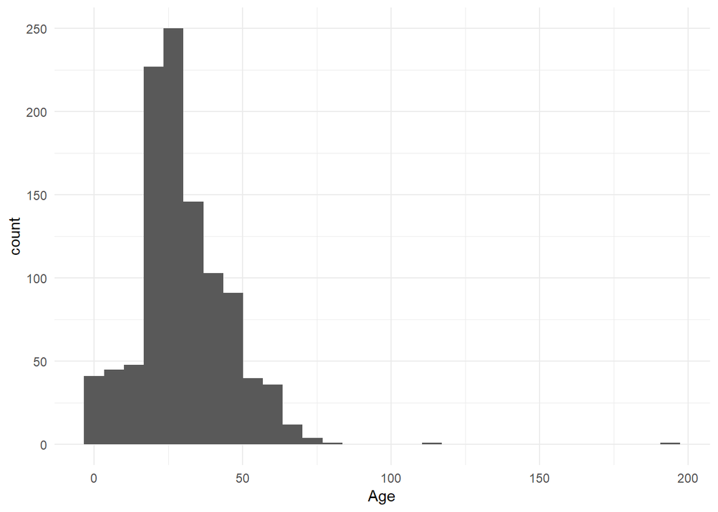

```r
library(ggplot2)
# plotando em um histograma
ggplot(data=full_dataset, aes(Age)) + geom_histogram(bins = 30) +  theme_minimal()
```

```r
# checando as instâncias em Age acima de 100 e substituindo por NA
full_dataset[(full_dataset$Age > 110 & !(is.na(full_dataset$Age))), ]$Age <- c(NA)
```

É possível também um encontrar um possível outlier no Fare.

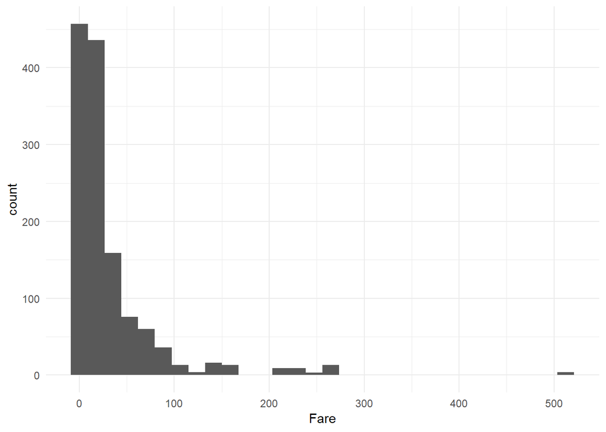

```r
# Fare
ggplot(data=full_dataset, aes(Fare)) + geom_histogram(bins = 30) +  theme_minimal()
```

Pelo menos 4 passageiros pagaram um valor bem elevado no ticket pesquisas adicionais apontam que de fato esse preço poderia ter sido pago por alguns passageiros como foi o caso de Cardeza, Mrs. James Warburton Martinez (Charlotte Wardle Drake) [Encyclopedia-Titanica]: https://www.encyclopedia-titanica.org/titanic-survivor/charlotte-cardeza.html

```r
full_dataset[(full_dataset$Fare > 450 & !(is.na(full_dataset$Fare))), ]
```

|  | Pclass | Name | Sex | Age | SibSp | Parch | Ticket | Fare | Cabin | Embarked | Survived |
| --- | --- | --- | --- | --- | --- | --- | --- | --- | --- | --- | --- |
| 259 | 1 | Ward, Miss. Anna | female | 35 | 0 | 0 | PC 17755 | 512.3292 |  | C | 1 |
| 680 | 1 | Cardeza, Mr. Thomas Drake Martinez | male | 36 | 0 | 1 | PC 17755 | 512.3292 | B51 B53 B55 | C | 1 |
| 738 | 1 | Lesurer, Mr. Gustave J | male | 35 | 0 | 0 | PC 17755 | 512.3292 | B101 | C | 1 |
| 1235 | 1 | Cardeza, Mrs. James Warburton Martinez (Charlotte Wardle Drake) | female | 58 | 0 | 1 | PC 17755 | 512.3292 | B51 B53 B55 | C | NA |

Checando os valores ausentes das colunas numéricas. Quase todas as variáveis numéricas possuem valores ausentes. Podemos ignorar Survived por que refere-se a imputação que fizemos acima.

```r
sapply(full_dataset, function(x) sum(is.na(x)))
```

```
##   Pclass     Name      Sex      Age    SibSp    Parch   Ticket     Fare
##        9        0       45      265        0        0        0        1
##    Cabin Embarked Survived
##        0        2      418
```

Agora podemos verificar as variáveis categóricas. Note que cabin possui aproximadamente 77,4% de dados ausentes, apesar de ser potencialmente relevante pode ser que tenhamos que removê-la.

```r
nrow(full_dataset[full_dataset$Cabin == "",])/nrow(full_dataset)
```

```
## [1] 0.7746371
```

```r
# a coluna nome está totalmente preenchida
nrow(full_dataset[full_dataset$Name == "",])/nrow(full_dataset)
```

```
## [1] 0
```

```r
# a coluna ticket está totalmente preenchida
nrow(full_dataset[full_dataset$Ticket == "",])/nrow(full_dataset)
```

```
## [1] 0
```

Com base na análise de instânicas ausentes poderemos destacar algumas variáveis: - Pclass = 9 instâncias - Sex = 45 instâncias - Age = 265 instâncias - Fare = 1 instância - Cabin = 1014 instâncias - Embarked = 2 instâncias

As variáveis que possuem uma quantidade menor de instâncias faremos uma imputação manual verificando o valor mais razoável que poderá ser atribuído. A priori não queremos perder nenhuma informação, primeiro vamos trabalhar na variável sexo:

```r
# carregando as instãncias não preenchidas da variável
full_dataset[!complete.cases(full_dataset$Sex),]
```

|  | Pclass | Name | Sex | Age | SibSp | Parch | Ticket | Fare | Cabin | Embarked | Survived |
| --- | --- | --- | --- | --- | --- | --- | --- | --- | --- | --- | --- |
| 34 | 2 | Wheadon, Mr. Edward H | NA | NA | 0 | 0 | C.A. 24579 | 10.5000 |  | S | 0 |
| 62 | 1 | Icard, Miss. Amelie | NA | 38 | 0 | 0 | 113572 | 80.0000 | B28 | NA | 1 |
| 68 | 3 | Crease, Mr. Ernest James | NA | 19 | 0 | 0 | S.P. 3464 | 8.1583 |  | S | 0 |
| 82 | 3 | Sheerlinck, Mr. Jan Baptist | NA | 29 | 0 | 0 | 345779 | 9.5000 |  | S | 1 |
| 191 | 2 | Pinsky, Mrs. (Rosa) | NA | 32 | 0 | 0 | 234604 | 13.0000 |  | S | 1 |
| 256 | 3 | Touma, Mrs. Darwis (Hanne Youssef Razi) | NA | 29 | 0 | 2 | 2650 | 15.2458 |  | C | 1 |
| 260 | 2 | Parrish, Mrs. (Lutie Davis) | NA | 50 | 0 | 1 | 230433 | 26.0000 |  | S | 1 |
| 266 | 2 | Reeves, Mr. David | NA | 36 | 0 | 0 | C.A. 17248 | 10.5000 |  | S | 0 |
| 329 | 3 | Goldsmith, Mrs. Frank John (Emily Alice Brown) | NA | 31 | 1 | 1 | 363291 | 20.5250 |  | S | 1 |
| 408 | 2 | Richards, Master. William Rowe | NA | 3 | 1 | 1 | 29106 | 18.7500 |  | S | 1 |

[output cut: 35 more lines]

É possível obter o sexo através da coluna **Name**, vamos quebrar essa variável.

```r
att_dataset <- NULL
for(ind in 1:length(full_dataset$Pclass)){
  full_dataset$LastName[ind] <- c(att_dataset, strsplit(as.character(full_dataset$Name), ",", fixed = TRUE))[[ind]][1]
  full_dataset$Name[ind] <- c(att_dataset, strsplit(as.character(full_dataset$Name), ",", fixed = TRUE))[[ind]][2]
}

# reordenar colunas
full_dataset <- full_dataset[,c(1,2,12,3:11)]
head(full_dataset)
```

|  | Pclass | Name | LastName | Sex | Age | SibSp | Parch | Ticket | Fare | Cabin | Embarked | Survived |
| --- | --- | --- | --- | --- | --- | --- | --- | --- | --- | --- | --- | --- |
| 1 | 3 | Mr. Owen Harris | Braund | male | 22 | 1 | 0 | A/5 21171 | 7.2500 |  | S | 0 |
| 2 | 1 | Mrs. John Bradley (Florence Briggs Thayer) | Cumings | female | 38 | 1 | 0 | PC 17599 | 71.2833 | C85 | C | 1 |
| 3 | 3 | Miss. Laina | Heikkinen | female | 26 | 0 | 0 | STON/O2. 3101282 | 7.9250 |  | S | 1 |
| 4 | 1 | Mrs. Jacques Heath (Lily May Peel) | Futrelle | female | 35 | 1 | 0 | 113803 | 53.1000 | C123 | S | 1 |
| 5 | 3 | Mr. William Henry | Allen | male | 35 | 0 | 0 | 373450 | 8.0500 |  | S | 0 |
| 6 | 3 | Mr. James | Moran | male | NA | 0 | 0 | 330877 | 8.4583 |  | Q | 0 |

```r
# vamos filtrar novamente apenas aquelas instâncias onde o sexo não está preenchido
library(stringr)

for(row in 1:nrow(full_dataset)){

  if (is.na(full_dataset$Sex)[row]){
    if(str_detect(full_dataset$Name[row], fixed("Mrs."))  | str_detect(full_dataset$Name[row], fixed("Miss.")) | str_detect(full_dataset$Name[row], fixed("Ms.")) | str_detect(full_dataset$Name[row], fixed("the Countess.")))
    {
      full_dataset$Sex[row] <- c("female")
    }else{
      full_dataset$Sex[row] <- c("male")
    }
  }
}
```

Analisando a variável **Cabin**. Grande parte (aprox. 87%) das cabines cadastradas são de primeira classe.

```r
table(subset(full_dataset, !Cabin == "", c(Pclass, Cabin))$Pclass)
```

```
##
##   1   2   3
## 254  23  16
```

```r
# verificar as instâncias não preenchidas de Pclass
full_dataset[is.na(full_dataset$Pclass),]
```

|  | Pclass | Name | LastName | Sex | Age | SibSp | Parch | Ticket | Fare | Cabin | Embarked | Survived |
| --- | --- | --- | --- | --- | --- | --- | --- | --- | --- | --- | --- | --- |
| 36 | NA | Mr. Alexander Oskar | Holverson | male | 42 | 1 | 0 | 113789 | 52.0000 |  | S | 0 |
| 162 | NA | Mrs. James (Elizabeth "Bessie" Inglis Milne) | Watt | female | 40 | 0 | 0 | C.A. 33595 | 15.7500 |  | S | 1 |
| 333 | NA | Mr. George Edward | Graham | male | 38 | 0 | 1 | PC 17582 | 153.4625 | C91 | S | 0 |
| 472 | NA | Mr. Luka | Cacic | male | 38 | 0 | 0 | 315089 | 8.6625 |  | S | 0 |
| 477 | NA | Mr. Peter Henry | Renouf | male | 34 | 1 | 0 | 31027 | 21.0000 |  | S | 0 |
| 620 | NA | Mr. Lawrence | Gavey | male | 26 | 0 | 0 | 31028 | 10.5000 |  | S | 0 |
| 704 | NA | Mr. Martin | Gallagher | male | 25 | 0 | 0 | 36864 | 7.7417 |  | Q | 0 |
| 814 | NA | Miss. Ebba Iris Alfrida | Andersson | female | 6 | 4 | 2 | 347082 | 31.2750 |  | S | 0 |
| 872 | NA | Mrs. Richard Leonard (Sallie Monypeny) | Beckwith | female | 47 | 1 | 1 | 11751 | 52.5542 | D35 | S | 1 |

Identificar se a coluna Ticket pode ajudar a preencher a coluna Pclass. É bem provável que os passageiros sejam da própria familia (conjuge) pagaram o mesmo valor na passagem e embarcaram do mesmo lugar. Assim atribuímos o mesmo Pclass.

```r
full_dataset[full_dataset$Ticket == "113789",]
```

|  | Pclass | Name | LastName | Sex | Age | SibSp | Parch | Ticket | Fare | Cabin | Embarked | Survived |
| --- | --- | --- | --- | --- | --- | --- | --- | --- | --- | --- | --- | --- |
| 36 | NA | Mr. Alexander Oskar | Holverson | male | 42 | 1 | 0 | 113789 | 52 |  | S | 0 |
| 384 | 1 | Mrs. Alexander Oskar (Mary Aline Towner) | Holverson | female | 35 | 1 | 0 | 113789 | 52 |  | S | 1 |

```r
# atribuindo o pclass
full_dataset[full_dataset$Ticket == "113789",][[1]][1] <- 1
```

Analisando o **Pclass**. Provavelmente ambos são da mesma familia. SibSp e Parch tem o valor zero. Também pagaram pelo mesmo o mesmo valor no ticket e embarcaram no mesmo local. Por isso, atribuímos o mesmo Pclass.

```r
full_dataset[full_dataset$Ticket == "C.A. 33595",]
```

|  | Pclass | Name | LastName | Sex | Age | SibSp | Parch | Ticket | Fare | Cabin | Embarked | Survived |
| --- | --- | --- | --- | --- | --- | --- | --- | --- | --- | --- | --- | --- |
| 162 | NA | Mrs. James (Elizabeth "Bessie" Inglis Milne) | Watt | female | 40 | 0 | 0 | C.A. 33595 | 15.75 |  | S | 1 |
| 1012 | 2 | Miss. Bertha J | Watt | female | 12 | 0 | 0 | C.A. 33595 | 15.75 |  | S | NA |

```r
full_dataset[full_dataset$Ticket == "C.A. 33595",][[1]][1] <- 2
```

Analisando o **Ticket**. É possível perceber que este passageiro compõe uma cabine preenchida, o que aumenta a probabilidade de pertencer a primeira classe. Além de possuir outros atributos semelhantes a outros passageiros com mesmo ticket. Atribuímos o mesmo Pclass.

```r
full_dataset[full_dataset$Ticket == "PC 17582",]
```

|  | Pclass | Name | LastName | Sex | Age | SibSp | Parch | Ticket | Fare | Cabin | Embarked | Survived |
| --- | --- | --- | --- | --- | --- | --- | --- | --- | --- | --- | --- | --- |
| 269 | 1 | Mrs. William Thompson (Edith Junkins) | Graham | female | 58 | 0 | 1 | PC 17582 | 153.4625 | C125 | S | 1 |
| 333 | NA | Mr. George Edward | Graham | male | 38 | 0 | 1 | PC 17582 | 153.4625 | C91 | S | 0 |
| 610 | 1 | Miss. Elizabeth W | Shutes | female | 40 | 0 | 0 | PC 17582 | 153.4625 | C125 | S | 1 |

```r
full_dataset[full_dataset$Ticket == "PC 17582",][[1]][2] <- 1
```

Vamos a outro passageiro.

```r
# outro passageiro
full_dataset[full_dataset$Ticket == "315089",]
```

|  | Pclass | Name | LastName | Sex | Age | SibSp | Parch | Ticket | Fare | Cabin | Embarked | Survived |
| --- | --- | --- | --- | --- | --- | --- | --- | --- | --- | --- | --- | --- |
| 472 | NA | Mr. Luka | Cacic | male | 38 | 0 | 0 | 315089 | 8.6625 |  | S | 0 |

Apenas um único registro. Podemos olhar para duas variáveis principais: a primeira o preço do ticket é baixo e poderia indicar que este passageiro está na classe 3. Também poderemos buscar pelo LastName algum possível parantesco familiar.

```r
full_dataset[full_dataset$LastName == "Cacic",]
```

|  | Pclass | Name | LastName | Sex | Age | SibSp | Parch | Ticket | Fare | Cabin | Embarked | Survived |
| --- | --- | --- | --- | --- | --- | --- | --- | --- | --- | --- | --- | --- |
| 472 | NA | Mr. Luka | Cacic | male | 38 | 0 | 0 | 315089 | 8.6625 |  | S | 0 |
| 535 | 3 | Miss. Marija | Cacic | female | 30 | 0 | 0 | 315084 | 8.6625 |  | S | 0 |
| 929 | 3 | Miss. Manda | Cacic | female | 21 | 0 | 0 | 315087 | 8.6625 |  | S | NA |
| 1202 | 3 | Mr. Jego Grga | Cacic | male | 18 | 0 | 0 | 315091 | 8.6625 |  | S | NA |

Detectamos que todos que carregam o mesmo sobrenome estão na classe 3. Por isso, atribuímos a classe 3.

```r
full_dataset[full_dataset$Ticket == "315089",][[1]][1] <- 3
```

Vamos a outro passageiro.

```r
full_dataset[full_dataset$Ticket == "31027",]
```

|  | Pclass | Name | LastName | Sex | Age | SibSp | Parch | Ticket | Fare | Cabin | Embarked | Survived |
| --- | --- | --- | --- | --- | --- | --- | --- | --- | --- | --- | --- | --- |
| 477 | NA | Mr. Peter Henry | Renouf | male | 34 | 1 | 0 | 31027 | 21 |  | S | 0 |
| 727 | 2 | Mrs. Peter Henry (Lillian Jefferys) | Renouf | female | 30 | 3 | 0 | 31027 | 21 |  | S | 1 |

Parece que este passageiro está mesmo na classe 2, quando observamos as outras variáveis.

```r
full_dataset[full_dataset$Ticket == "31027",][[1]][1] <- 2
```

Próximo passageiro.

```r
full_dataset[full_dataset$Ticket == "31028",]
```

|  | Pclass | Name | LastName | Sex | Age | SibSp | Parch | Ticket | Fare | Cabin | Embarked | Survived |
| --- | --- | --- | --- | --- | --- | --- | --- | --- | --- | --- | --- | --- |
| 620 | NA | Mr. Lawrence | Gavey | male | 26 | 0 | 0 | 31028 | 10.5 |  | S | 0 |

Pelo preço talvez este passageiro esteja alocado na classe 3. Vamos observar o LastName.

```r
full_dataset[full_dataset$LastName == "Gavey",]
```

|  | Pclass | Name | LastName | Sex | Age | SibSp | Parch | Ticket | Fare | Cabin | Embarked | Survived |
| --- | --- | --- | --- | --- | --- | --- | --- | --- | --- | --- | --- | --- |
| 620 | NA | Mr. Lawrence | Gavey | male | 26 | 0 | 0 | 31028 | 10.5 |  | S | 0 |

Não ajudou muito, é o único com este LastName. Pesquisas externas apontam que ele embarcou na classe 2.

```r
full_dataset[full_dataset$Ticket == "31028",][[1]][1] <- 2
```

Vamos aos próximos pclass não preenchidos.

```r
full_dataset[is.na(full_dataset$Pclass),]
```

|  | Pclass | Name | LastName | Sex | Age | SibSp | Parch | Ticket | Fare | Cabin | Embarked | Survived |
| --- | --- | --- | --- | --- | --- | --- | --- | --- | --- | --- | --- | --- |
| 704 | NA | Mr. Martin | Gallagher | male | 25 | 0 | 0 | 36864 | 7.7417 |  | Q | 0 |
| 814 | NA | Miss. Ebba Iris Alfrida | Andersson | female | 6 | 4 | 2 | 347082 | 31.2750 |  | S | 0 |
| 872 | NA | Mrs. Richard Leonard (Sallie Monypeny) | Beckwith | female | 47 | 1 | 1 | 11751 | 52.5542 | D35 | S | 1 |

Temos ainda três passageiros sem Pclass.

```r
full_dataset[full_dataset$Ticket == "36864",]
```

|  | Pclass | Name | LastName | Sex | Age | SibSp | Parch | Ticket | Fare | Cabin | Embarked | Survived |
| --- | --- | --- | --- | --- | --- | --- | --- | --- | --- | --- | --- | --- |
| 704 | NA | Mr. Martin | Gallagher | male | 25 | 0 | 0 | 36864 | 7.7417 |  | Q | 0 |

O preço pode indicar que este passageiro esteve na classe 3. Vamos ao Last Lame.

```r
full_dataset[full_dataset$LastName == "Gallagher",]
```

|  | Pclass | Name | LastName | Sex | Age | SibSp | Parch | Ticket | Fare | Cabin | Embarked | Survived |
| --- | --- | --- | --- | --- | --- | --- | --- | --- | --- | --- | --- | --- |
| 704 | NA | Mr. Martin | Gallagher | male | 25 | 0 | 0 | 36864 | 7.7417 |  | Q | 0 |

Da mesma maneira que no caso anterior o passageiro é o único com este sobrenome. Pesquisas externas confirmam nossa suposição de que ele viajou na classe 3.

```r
full_dataset[full_dataset$Ticket == "36864",][[1]][1] <- 3
```

Próximo passageiro.

```r
full_dataset[full_dataset$Ticket == "347082",]
```

|  | Pclass | Name | LastName | Sex | Age | SibSp | Parch | Ticket | Fare | Cabin | Embarked | Survived |
| --- | --- | --- | --- | --- | --- | --- | --- | --- | --- | --- | --- | --- |
| 14 | 3 | Mr. Anders Johan | Andersson | male | 39 | 1 | 5 | 347082 | 31.275 |  | S | 0 |
| 120 | 3 | Miss. Ellis Anna Maria | Andersson | female | 2 | 4 | 2 | 347082 | 31.275 |  | S | 0 |
| 542 | 3 | Miss. Ingeborg Constanzia | Andersson | female | 9 | 4 | 2 | 347082 | 31.275 |  | S | 0 |
| 543 | 3 | Miss. Sigrid Elisabeth | Andersson | female | 11 | 4 | 2 | 347082 | 31.275 |  | S | 0 |
| 611 | 3 | Mrs. Anders Johan (Alfrida Konstantia Brogren) | Andersson | female | 39 | 1 | 5 | 347082 | 31.275 |  | S | 0 |
| 814 | NA | Miss. Ebba Iris Alfrida | Andersson | female | 6 | 4 | 2 | 347082 | 31.275 |  | S | 0 |
| 851 | 3 | Master. Sigvard Harald Elias | Andersson | male | 4 | 4 | 2 | 347082 | 31.275 |  | S | 0 |

Os resultados indicam uma alta probabilidade de ser da classe 3, especialmente pelo parantesco.

```r
full_dataset[full_dataset$Ticket == "347082",][[1]][6] <- 3
```

Nosso último passageiro.

```r
full_dataset[full_dataset$Ticket == "11751",]
```

|  | Pclass | Name | LastName | Sex | Age | SibSp | Parch | Ticket | Fare | Cabin | Embarked | Survived |
| --- | --- | --- | --- | --- | --- | --- | --- | --- | --- | --- | --- | --- |
| 249 | 1 | Mr. Richard Leonard | Beckwith | male | 37 | 1 | 1 | 11751 | 52.5542 | D35 | S | 1 |
| 872 | NA | Mrs. Richard Leonard (Sallie Monypeny) | Beckwith | female | 47 | 1 | 1 | 11751 | 52.5542 | D35 | S | 1 |

Não existem informações suficientes para concluir sobre a classe desse passageiro. Vamos ao LastName.

```r
full_dataset[full_dataset$LastName == "Beckwith",]
```

|  | Pclass | Name | LastName | Sex | Age | SibSp | Parch | Ticket | Fare | Cabin | Embarked | Survived |
| --- | --- | --- | --- | --- | --- | --- | --- | --- | --- | --- | --- | --- |
| 249 | 1 | Mr. Richard Leonard | Beckwith | male | 37 | 1 | 1 | 11751 | 52.5542 | D35 | S | 1 |
| 872 | NA | Mrs. Richard Leonard (Sallie Monypeny) | Beckwith | female | 47 | 1 | 1 | 11751 | 52.5542 | D35 | S | 1 |

Parece que existe um vínculo entre os passageiros em questão assim podemos atribuir a classe 1.

```r
full_dataset[full_dataset$Ticket == "11751",][[1]][2] <- 1
```

Atualizando nossa tabela de instâncias não preenchidas:

- Pclass = 9 instâncias (OK)
- Sex = 45 instâncias (OK)
- Age = 265 instâncias
- Fare = 1 instância
- Cabin = 1014 instâncias
- Embarked = 2 instâncias

Manualmente poderemos também preencher as instâncias das variáveis Fare e Embarked.

Vamos a **Fare**, primeiramente.

```r
full_dataset[!complete.cases(full_dataset$Fare),]
```

|  | Pclass | Name | LastName | Sex | Age | SibSp | Parch | Ticket | Fare | Cabin | Embarked | Survived |
| --- | --- | --- | --- | --- | --- | --- | --- | --- | --- | --- | --- | --- |
| 1044 | 3 | Mr. Thomas | Storey | male | 60 | 0 | 0 | 3701 | NA |  | S | NA |

Temos algumas pistas que podem ser úteis para setar um valor para esta instância. Observe a Pclass igual a 3. Vamos verificar os valores extremos pagos por passageiros desta classe.

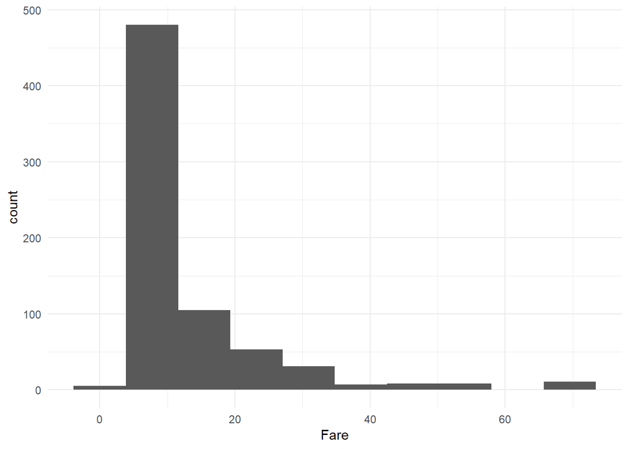

```r
extract_subset <- subset(full_dataset, full_dataset$Pclass == 3, select = c(Pclass,LastName,Embarked,Fare))

# plotando em um histograma
ggplot(data=extract_subset, aes(Fare)) + geom_histogram(bins = 10) +  theme_minimal()
```

Vamos observar outras colunas. LastName não oferece nenhuma informação adicional.

```r
extract_subset[extract_subset$LastName == "Storey",]
```

|  | Pclass | LastName | Embarked | Fare |
| --- | --- | --- | --- | --- |
| 1044 | 3 | Storey | S | NA |

Total de pesssoas que embarcaram em Southampton.s

```r
nrow(extract_subset[extract_subset$Embarked == "S",])
```

```
## [1] 495
```

Certo, mas qual o preço médio do ticket cobrado por lá?

```r
extract_embarked_s <- extract_subset[extract_subset$Embarked == "S",]

summary(extract_embarked_s)
```

```
##  Pclass    LastName         Embarked      Fare
##  1:  0   Length:495         C:  0    Min.   : 0.000
##  2:  0   Class :character   Q:  0    1st Qu.: 7.854
##  3:495   Mode  :character   S:495    Median : 8.050
##                                      Mean   :14.435
##                                      3rd Qu.:15.900
##                                      Max.   :69.550
##                                      NA's   :1
```

Nesse caso, seria interessante olhar para a mediana do que a média por conta dos valores discrepantes. Assim,temos que a mediana da variável é 8.05. Considerando que o preço da tarifa para esse passageiro não seja tão diferente dos demais vamos verificar quais são os preços mais comumentes praticados.

```r
df_freq_fare<-data.frame(table(extract_embarked_s$Fare))
colnames(df_freq_fare) <- c("fare",'freq')
df_freq_fare[order(df_freq_fare$freq, decreasing = TRUE),]
```

|  | fare | freq |
| --- | --- | --- |
| 32 | 8.05 | 60 |
| 30 | 7.8958 | 43 |
| 22 | 7.775 | 26 |
| 31 | 7.925 | 23 |
| 26 | 7.8542 | 21 |
| 40 | 8.6625 | 20 |
| 13 | 7.25 | 17 |
| 52 | 9.5 | 12 |
| 74 | 16.1 | 12 |
| 97 | 69.55 | 11 |

[output cut: 87 more lines]

Observe que além da mediana os valores entre 7 e 8 são mais comuns. Decidimos setar a mediana para esta instância.

```r
full_dataset[!complete.cases(full_dataset$Fare),][,c("Fare")] <- median(extract_embarked_s$Fare, na.rm = TRUE)
```

Dando prosseguimento iremos avaliar as instâncias de **Embarked**.

```r
full_dataset[!complete.cases(full_dataset$Embarked),]
```

|  | Pclass | Name | LastName | Sex | Age | SibSp | Parch | Ticket | Fare | Cabin | Embarked | Survived |
| --- | --- | --- | --- | --- | --- | --- | --- | --- | --- | --- | --- | --- |
| 62 | 1 | Miss. Amelie | Icard | female | 38 | 0 | 0 | 113572 | 80 | B28 | NA | 1 |
| 830 | 1 | Mrs. George Nelson (Martha Evelyn) | Stone | female | 62 | 0 | 0 | 113572 | 80 | B28 | NA | 1 |

Checando a coluna LastName, na tentativa de identificar pistas de vinculos familiares que podem indicar que embarcaram de um mesmo local. Nenhuma informação adicional.

```r
full_dataset[full_dataset$LastName == "Icard",]
```

|  | Pclass | Name | LastName | Sex | Age | SibSp | Parch | Ticket | Fare | Cabin | Embarked | Survived |
| --- | --- | --- | --- | --- | --- | --- | --- | --- | --- | --- | --- | --- |
| 62 | 1 | Miss. Amelie | Icard | female | 38 | 0 | 0 | 113572 | 80 | B28 | NA | 1 |

```r
full_dataset[full_dataset$LastName == "Stone",]
```

|  | Pclass | Name | LastName | Sex | Age | SibSp | Parch | Ticket | Fare | Cabin | Embarked | Survived |
| --- | --- | --- | --- | --- | --- | --- | --- | --- | --- | --- | --- | --- |
| 830 | 1 | Mrs. George Nelson (Martha Evelyn) | Stone | female | 62 | 0 | 0 | 113572 | 80 | B28 | NA | 1 |

Será que o número do ticket poderia ajudar? Ambos tem o mesmo número de ticket. Aparentemente não.

```r
full_dataset[full_dataset$Ticket == "113572",]
```

|  | Pclass | Name | LastName | Sex | Age | SibSp | Parch | Ticket | Fare | Cabin | Embarked | Survived |
| --- | --- | --- | --- | --- | --- | --- | --- | --- | --- | --- | --- | --- |
| 62 | 1 | Miss. Amelie | Icard | female | 38 | 0 | 0 | 113572 | 80 | B28 | NA | 1 |
| 830 | 1 | Mrs. George Nelson (Martha Evelyn) | Stone | female | 62 | 0 | 0 | 113572 | 80 | B28 | NA | 1 |

O preço do ticket pode ser útil para indicar o local de embarque? Também não.

```r
full_dataset[full_dataset$Fare == 80,]
```

|  | Pclass | Name | LastName | Sex | Age | SibSp | Parch | Ticket | Fare | Cabin | Embarked | Survived |
| --- | --- | --- | --- | --- | --- | --- | --- | --- | --- | --- | --- | --- |
| 62 | 1 | Miss. Amelie | Icard | female | 38 | 0 | 0 | 113572 | 80 | B28 | NA | 1 |
| 830 | 1 | Mrs. George Nelson (Martha Evelyn) | Stone | female | 62 | 0 | 0 | 113572 | 80 | B28 | NA | 1 |

Qual o local mais comum de embarque? Hum, Southampton.

```r
# Em termos de proporção aproximadamente 70% dos embarques são feitos por lá.
prop.table(table(full_dataset$Embarked))
```

```
##
##          C          Q          S
## 0.20657995 0.09410865 0.69931140
```

Buscamos essa informação externamente e realmente constatamos que ambos desembarcaram em Southampton. Assim, podemos preencher essa instância de forma mais segura.

```r
full_dataset[!complete.cases(full_dataset$Embarked),][,c("Embarked")] <- c("S","S")
```

Atualizando as variáveis para preenchimento:

- Pclass = 9 instâncias (OK)
- Sex = 45 instâncias (OK)
- Age = 265 instâncias
- Fare = 1 instância (OK)
- Cabin = 1014 instâncias
- Embarked = 2 instâncias (OK)

Restaram apenas duas variáveis: **Age** e **Cabin**. Sabemos que a idade pode ser um fator importante de sobrevivência. A cabine também poderia ser uma informação importante. No entanto, temos uma quantidade imensa de valores não preenchidas. Assim decidimos, nessa primeira análise, remover a variável **Cabin**. Além disso, entendemos que a Pclass poderia amenizar a ausência da variável Cabin uma vez que a Pclass pode fornecer uma noção da posição espacial dos passageiros no navio.

Para a variável **Age** realizaremos a imputação utilizando uma abordagem preditiva utilizando o KNN.

```r
full_dataset <- subset(full_dataset, select = c(Pclass:Fare, Embarked:Survived))

# realizando a imputação com o KNN
library(DMwR)
sub_full_dataset <- full_dataset[,c("Pclass","Sex","Age","Fare","Embarked")]

# convertendo atributos categóricos em numéricos
sub_full_dataset$Sex <- ifelse(sub_full_dataset$Sex == "male", 1, 2)
levels(sub_full_dataset$Embarked) <- c(1,2,3)
sub_full_dataset$Age <- as.integer(sub_full_dataset$Age)

full_dataset_transf <- knnImputation(sub_full_dataset, k = 10, scale = T)
full_dataset_transf$Age <- as.integer(full_dataset_transf$Age)
```

Vamos verificar quão diferente ficou a distribuição após a imputação dos dados na variável Age. A imputação manteve uma distribuição dos dados bem aproximada do conjunto de dados original.

```r
# Antes
summary(full_dataset$Age)
```

```
##    Min. 1st Qu.  Median    Mean 3rd Qu.    Max.    NA's
##     0.0    21.0    28.0    29.8    39.0    80.0     265
```

```r
cat("\n")
```

```r
# Depois
summary(full_dataset_transf$Age)
```

```
##    Min. 1st Qu.  Median    Mean 3rd Qu.    Max.
##    0.00   21.00   28.00   29.52   36.00   80.00
```

Agora finalizaremos a etapa de transformação ajustando o nosso dataset.

```r
full_dataset$Age <- full_dataset_transf$Age

# agora podemos selecionar somente as variáveis que interessam para o restante das etapas.
str(full_dataset)
```

```
## 'data.frame':    1309 obs. of  11 variables:
##  $ Pclass  : Factor w/ 3 levels "1","2","3": 3 1 3 1 3 3 1 3 3 2 ...
##  $ Name    : chr  " Mr. Owen Harris" " Mrs. John Bradley (Florence Briggs Thayer)" " Miss. Laina" " Mrs. Jacques Heath (Lily May Peel)" ...
##  $ LastName: chr  "Braund" "Cumings" "Heikkinen" "Futrelle" ...
##  $ Sex     : Factor w/ 2 levels "female","male": 2 1 1 1 2 2 2 2 1 1 ...
##  $ Age     : int  22 38 26 35 35 36 54 2 27 14 ...
##  $ SibSp   : int  1 1 0 1 0 0 0 3 0 1 ...
##  $ Parch   : int  0 0 0 0 0 0 0 1 2 0 ...
##  $ Ticket  : Factor w/ 929 levels "110152","110413",..: 524 597 670 50 473 276 86 396 345 133 ...
##  $ Fare    : num  7.25 71.28 7.92 53.1 8.05 ...
##  $ Embarked: Factor w/ 3 levels "C","Q","S": 3 1 3 3 3 2 3 3 3 1 ...
##  $ Survived: int  0 1 1 1 0 0 0 0 1 1 ...
```

```r
full_dataset_transformed <- subset(full_dataset, select = c(Pclass,Sex,Age,SibSp,Parch,Fare,Embarked,Survived))
```

Neste momento começaremos a realizar explorações no dataset a fim de ter uma melhor compreensão a respeito dos dados.

**Dicionário de dados**

- survived: passageiro sobreviveu ou não? (0 = Não, 1 = Sim)
- pclass: classe da passagem no navio. (1 = primeira classe, 2 = classe executiva, 3 = classe econômica)
- name: nome do passageiro
- sex: gênero do passageiro
- sibsp: número de irmãos/companheiros dentro do navio
- parch: número de parentes e filhos no navio ticket
- ticket: código da passagem
- fare: valor da passagem
- cabin: número da cabine
- embarked: local onde o titanic embarcou. (C = Cherbourg, Q = Queenstown, S = Southampton)

```r
library(dplyr)
```

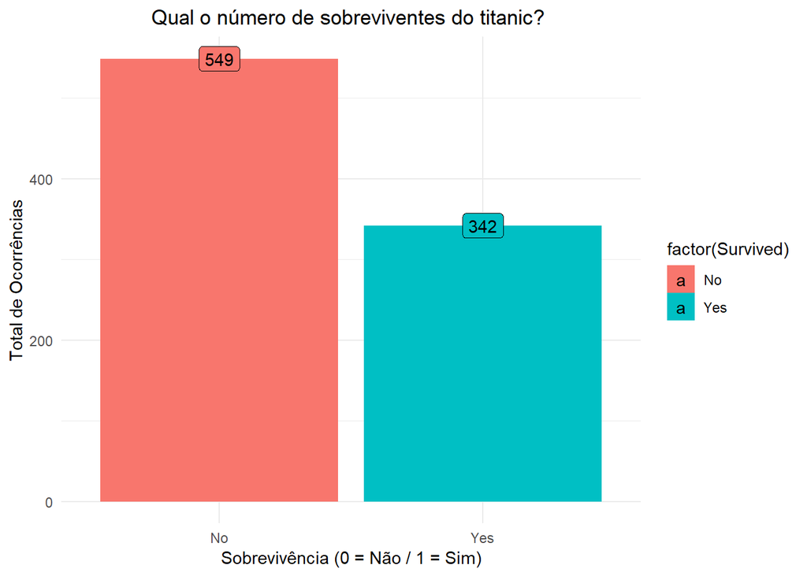

```r
library(knitr)
library(ggplot2)
library(gridExtra)
full_dataset_transformed %>%
  na.omit() %>%  mutate(Survived = ifelse(Survived == 1, "Yes", "No")) %>%
  ggplot(aes(x = Survived, fill = factor(Survived))) +
  geom_bar(stat="count") +
  ggtitle("Qual o número de sobreviventes do titanic? ") +
  geom_label(stat = "count", aes(label=..count..)) +
  scale_x_discrete(limits=c("No","Yes")) +
  xlab("Sobrevivência (0 = Não / 1 = Sim)") + ylab("Total de Ocorrências") +
  theme_minimal() +
  theme(plot.title = element_text(hjust = 0.5, vjust = 1))
```

```r
prop_surv <- full_dataset_transformed %>%
  na.omit() %>%
  count(Survived) %>%
  mutate(prop = n / sum(n))

kable(prop_surv)
```

| Survived | n | prop |
| --- | --- | --- |
| 0 | 549 | 0.6161616 |
| 1 | 342 | 0.3838384 |

Nosso primeiro insight é de que o percentual de pessoas que sobreviveram ao desastre foi de apenas 38%. Enquanto que pessoas que não sobreviveram representam mais de 60% do dataset.

Observando o **Pclass**.

```r
# Pclass
plot_pclass <- full_dataset_transformed %>%
  na.omit() %>% mutate(Survived = ifelse(Survived == 1, "Yes", "No")) %>%
  ggplot(aes(Pclass, fill = Survived)) +
  geom_bar() +
  ggtitle("Pclass") +
  geom_text(aes(label=..count..),stat="count",position=position_stack(0.9)) +
  labs(fill='Survived') +
  xlab("Class") + ylab("Total") +
  facet_wrap(~Pclass, scale = "free") +
  theme(plot.title = element_text(hjust = 0.5, vjust = 1))

prop_surv <- full_dataset_transformed %>%
  na.omit() %>%
  count(Survived, Pclass) %>%
  group_by(Pclass) %>%
  mutate(prop = n / sum(n)) %>% arrange(desc(Survived))

kable(prop_surv)
```

| Survived | Pclass | n | prop |
| --- | --- | --- | --- |
| 1 | 1 | 136 | 0.6296296 |
| 1 | 2 | 87 | 0.4728261 |
| 1 | 3 | 119 | 0.2423625 |
| 0 | 1 | 80 | 0.3703704 |
| 0 | 2 | 97 | 0.5271739 |
| 0 | 3 | 372 | 0.7576375 |

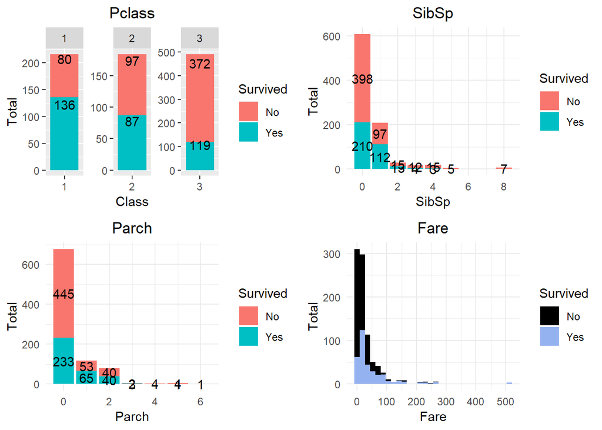

```r
# SibSP
plot_sibsp <- full_dataset_transformed %>%
  na.omit() %>% mutate(Survived = ifelse(Survived == 1, "Yes", "No")) %>%
  ggplot(aes(SibSp, fill = Survived)) +
  geom_bar() +
  ggtitle("SibSp") +
  xlab("SibSp") + ylab("Total") +
  geom_text(aes(label=..count..),stat="count",position=position_stack(0.5)) +
  theme_minimal() +
  theme(plot.title = element_text(hjust = 0.5, vjust = 1))

# Parch
plot_parch <- full_dataset_transformed %>%
  na.omit() %>% mutate(Survived = ifelse(Survived == 1, "Yes", "No")) %>%
  ggplot(aes(Parch, fill = Survived)) +
  geom_bar() +
  ggtitle("Parch") +
  xlab("Parch") + ylab("Total") +
  geom_text(aes(label=..count..),stat="count",position=position_stack(0.5)) +
  theme_minimal() +
  theme(plot.title = element_text(hjust = 0.5, vjust = 1))

# Fare
plot_fare <- full_dataset_transformed %>%
  na.omit() %>% mutate(Survived = ifelse(Survived == 1, "Yes", "No")) %>%
  ggplot(aes(Fare, fill = Survived)) +
  geom_histogram(bins =  30) +
  scale_fill_manual(values=c("#000000", "#95b2f0")) +
  ggtitle("Fare") +
  xlab("Fare") + ylab("Total") +
  theme_minimal() +
  theme(plot.title = element_text(hjust = 0.5, vjust = 1))

grid.arrange(plot_pclass, plot_sibsp, plot_parch, plot_fare, nrow = 2)
```

Analisando os gráficos, podemos concluir que:

1. **Pclass**:
- A classe 3 possui o maior número de passageiros. é possível perceber que houve um maior número de fatalidades nas classes menos privilegiadas. A primeira classe foi a única que houve maior número de sobreviventes. De fato, em termos proporcionais constata-se que grande parte dos passageiros da primeira classe sobreviveram enquanto que a taxa de sobrevivência é baixa para os passageiros da terceira classe apenas (24% aprox.) sobreviveram.
2. **SibSp**:
- Grande parte dos passageiros não possuem irmãos/companheiros. Curioso notar que o número de sobreviventes foi maior em situações onde os passageiros estiveram acompanhados de 1 irmão/companheiro.
3. **Parch**:
- uma quantidade mais equilibrada entre sobreviventes foi alcançada quando os passageiros estiveram acompanhados de parentes/filhos. O que faz sentido quando pensamos que, em situações de emergência, crianças tiveram prioridade.
4. **Fare**:
- Boa parte dos passageiros pagaram até 100 pelo ingresso. Em geral, a proporção de sobreviventes aumentou junto com o preço do ingresso. Esse insight está relacionado com o que foi obtido na variável pclass. Parece que houve prioridade de emergência a passageiros que pagaram mais pela passagem (ou estiveram em classes superiores). Sem comentar o fato de que a primeira classe ficasse em localização privilegiada (parte superior do navio).

Continuaremos nossa análise agora observando outras variáveis.

```r
# Embarked
plot_embarked <-  full_dataset_transformed %>%
  na.omit() %>% mutate(Survived = ifelse(Survived == 1, "Yes", "No")) %>%
  ggplot(aes(Embarked, fill = Survived)) +
  geom_bar() +
  ggtitle("Embarked") +
  xlab("Embarked") + ylab("Total") +
  geom_text(aes(label=..count..),stat="count",position=position_stack(0.5)) +
  theme(plot.title = element_text(hjust = 0.5, vjust = 1))

prop_surv <- full_dataset_transformed %>%
  na.omit() %>%
  count(Survived, Embarked) %>%
  group_by(Embarked) %>%
  mutate(prop = n / sum(n)) %>% arrange(desc(Survived))

kable(prop_surv)
```

| Survived | Embarked | n | prop |
| --- | --- | --- | --- |
| 1 | C | 93 | 0.5535714 |
| 1 | Q | 30 | 0.3896104 |
| 1 | S | 219 | 0.3390093 |
| 0 | C | 75 | 0.4464286 |
| 0 | Q | 47 | 0.6103896 |
| 0 | S | 427 | 0.6609907 |

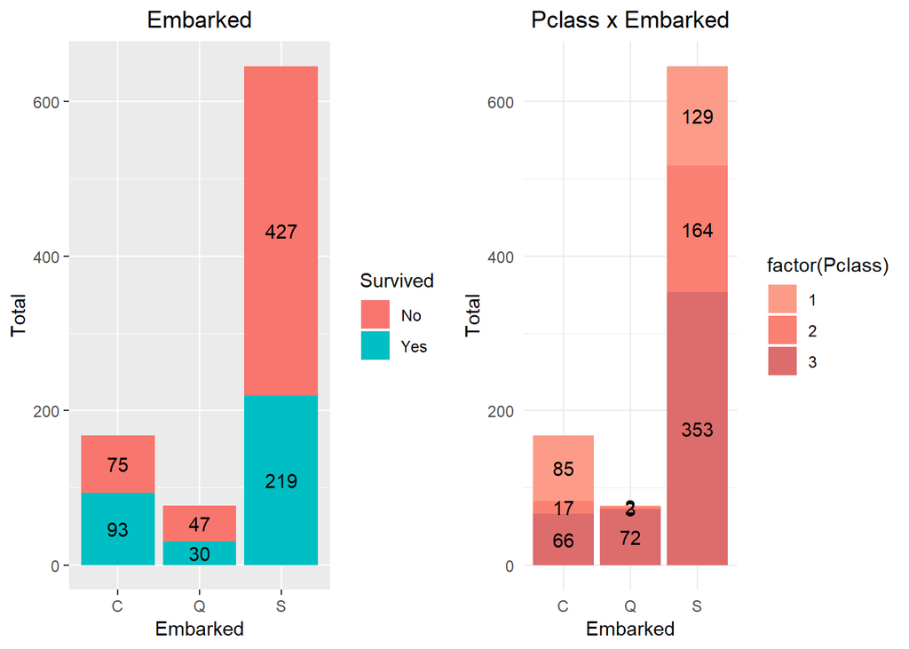

```r
# Classe do Embarque
plot_embarked_pclass <- full_dataset_transformed %>%
  na.omit() %>% mutate(Survived = ifelse(Survived == 1, "Yes", "No")) %>%
  ggplot(aes(Embarked, fill = factor(Pclass))) +
  geom_bar() +
  scale_fill_manual(values=c("#fd9b89", "#fa8072", "#dd6c6c")) +
  ggtitle("Pclass x Embarked") +
  xlab("Embarked") + ylab("Total") +
  geom_text(aes(label=..count..),stat="count",position=position_stack(0.5)) +
  theme_minimal() +
  theme(plot.title = element_text(hjust = 0.5, vjust = 1))


grid.arrange(plot_embarked, plot_embarked_pclass, nrow = 1)
```

Analisando os gráficos, podemos concluir que:

1. **Embarked**:
- A quantidade de sobreviventes foi maior que o número de fatalidades apenas para passageiros que embarcaramem em C (Cherbourg). Podemos mergulhar um pouco a fim de observar a Pclass mais frequentes dos passageiros que embarcaram em C.
2. **Embarked x Pclass**:
- Analisando a classe dos embarques, concluimos que o embarque de passageiros em C (Cherbourg) obteve a menor quantidade de passageiros da classe 3 o que pode ter contribuído para minimizar o percentual de mortalidade de passageiros que embarcaram neste local.

Agora vamos avaliar o **Sexo** em relação a cada classe de sobrevivência.

```r
# Sex
plot_sex <- full_dataset_transformed %>%
  na.omit() %>% mutate(Survived = ifelse(Survived == 1, "Yes", "No")) %>%
  ggplot(aes(Sex, fill = Survived)) +
  geom_bar() +
  ggtitle("Sex") +
  scale_fill_manual(values=c("#e4888b", "#4773aa")) +
  geom_text(aes(label=..count..),stat="count",position=position_stack(0.9)) +
  labs(fill='Survived') +
  xlab("Sex") + ylab("Total") +
  theme(plot.title = element_text(hjust = 0.5, vjust = 1))

prop_surv <- full_dataset_transformed %>%
  na.omit() %>%
  count(Survived, Sex) %>%
  group_by(Sex) %>%
  mutate(prop = n / sum(n)) %>% arrange(desc(Survived))

kable(prop_surv)
```

| Survived | Sex | n | prop |
| --- | --- | --- | --- |
| 1 | female | 233 | 0.7420382 |
| 1 | male | 109 | 0.1889081 |
| 0 | female | 81 | 0.2579618 |
| 0 | male | 468 | 0.8110919 |

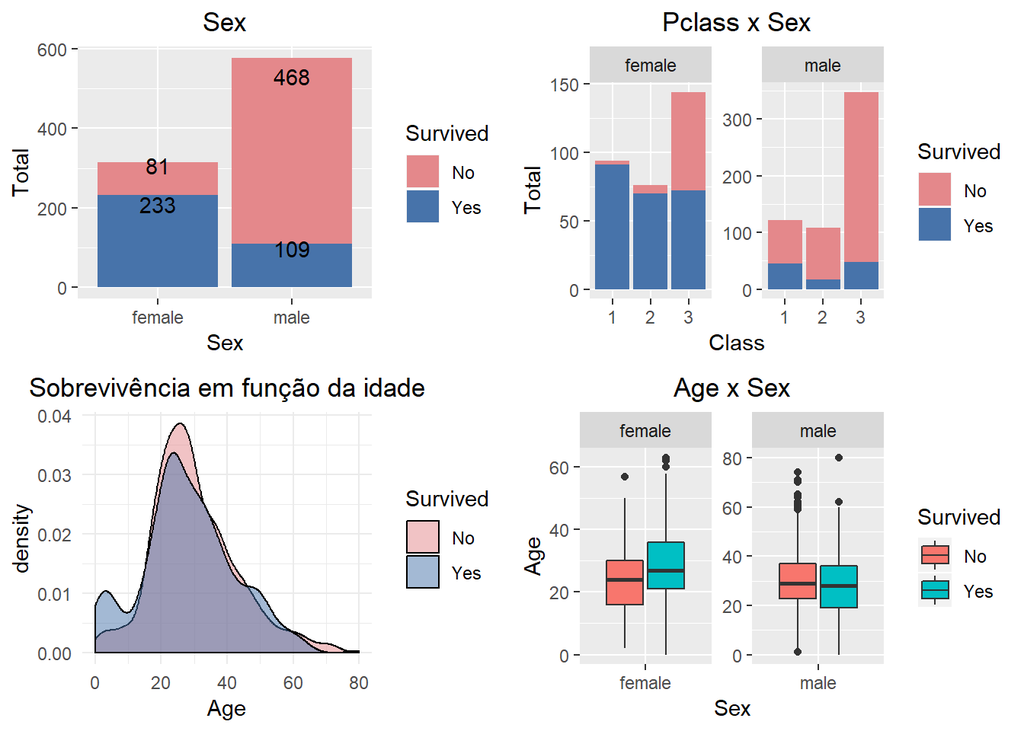

```r
# Pclass x Sex
plot_sex_class <- full_dataset_transformed %>%
  na.omit() %>% mutate(Survived = ifelse(Survived == 1, "Yes", "No")) %>%
  ggplot(aes(Pclass, fill = factor(Survived))) +
  geom_bar() +
  ggtitle("Pclass x Sex") +
  scale_fill_manual(values=c("#e4888b", "#4773aa")) +
  labs(fill='Survived') +
  xlab("Class") + ylab("Total") +
  facet_wrap(~Sex, scale = "free") +
  theme(plot.title = element_text(hjust = 0.5, vjust = 1))

# Age (taxa de sobrevivência)
plot_age <- full_dataset_transformed %>%
  na.omit() %>% mutate(Survived = ifelse(Survived == 1, "Yes", "No")) %>%
  ggplot(aes(x = Age, fill = Survived)) +
  geom_density(alpha=0.5, aes(fill=factor(Survived))) +
  ggtitle("Sobrevivência em função da idade") +
  scale_fill_manual(values=c("#e4888b", "#4773aa")) +
  scale_x_continuous() +
  theme_minimal() +
  theme(plot.title = element_text(hjust = 0.5))

# Age x Sex
plot_age_class <- full_dataset_transformed %>%
  na.omit() %>% mutate(Survived = ifelse(Survived == 1, "Yes", "No")) %>%
  ggplot(aes(Sex, Age, fill = factor(Survived))) +
  geom_boxplot() +
  ggtitle("Age x Sex") +
  labs(fill='Survived') +
  facet_wrap(~Sex, scale = "free") +
  theme(plot.title = element_text(hjust = 0.5, vjust = 1))


grid.arrange(plot_sex, plot_sex_class, plot_age, plot_age_class, nrow = 2)
```

Analisando os gráficos, podemos concluir que:

1. **Sex**:
- Claramente percebemos que passageiros do sexo feminino tiveram uma taxa de sobrevivência maior que os passageiros do sexo masculino. Em termos proporcionais, 74% de mulheres aproximadamente sobreviveram enquanto que no lado masculino apenas 19% aprox. sobreviveram.
2. **Pclass x Sex**:
- Grande parte das mulheres das classes 1 e 2 sobreviveram.
3. **Age**:
- A curva de densidade demonstra que crianças possuem a maior taxa de sobrevivência. Enquanto que para adultos acima de 30 anos, a curva de densidade oscilou em torno da média. Por fim, os maiores picos de mortalidade ficaram entre jovens adultos entre 25-30 anos.
4. **Age x Sex**:
- Entre os sobreviventes do sexo feminino a média da idade é mais alta. O que poderia indicar a existências de mães. Assim, é provável que as mamães e seus filhos tiveram prioridade nas situações mais tensas.

Para uma compreensão final a respeito dos dados, podemos analisar a correlação entre eles.

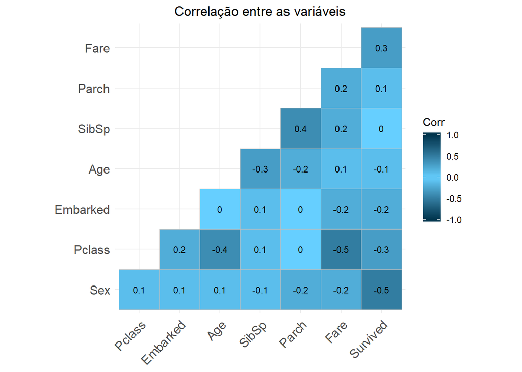

```r
library(ggcorrplot)

full_dataset_cor <- full_dataset_transformed %>%
  na.omit()

full_dataset_cor <- as.data.frame(sapply(full_dataset_cor, function(x) as.numeric(x)))

full_dataset_cor %>%
  cor(full_dataset_cor) %>% round(digits = 1) %>%
  ggcorrplot(hc.order = TRUE,
             type = "lower",
             lab = TRUE,
             title = "Correlação entre as variáveis",
             lab_size = 3,
             method="square",
             colors =c("#00344c", "#66cfff", "#00344c"),
             ggtheme=theme_minimal() + theme(plot.title = element_text(hjust = 0.5)))
```

Note que o gráfico sugere que as variáveis mais correlacionadas a **Survived** são: **Sex**, **Fare** e **Pclass**. A correlação entre as outras variáveis demonstra que:

- Parch possui maior correlação com SibSp. O que faz sentido, já que ambas estão relacionadas ao contexto família.
- Age possui maior correlação com Pclass.
- Fare possui maior correlação com Pclass.

A partir dessas análises explorátorias já temos uma boa noção do conjunto de dados. Então vamos pensar na etapa que antecede a construção do modelo: a seleção de features. Utilizaremos o algoritmo de eliminação recursiva (RFE) para selecionar as melhores features.

```r
library(caret)

# selecionaremos os dados que utilizaremos nessa etapa
select_data_train <- full_dataset_transformed %>% na.omit()

select_data_train$Survived <- as.factor(select_data_train$Survived)

dim(select_data_train)
```

```
## [1] 891   8
```

```r
ctr_rfe <- rfeControl(functions=rfFuncs, method="cv", number=10)

set.seed(123)

# algoritmo para seleção das melhores features para o modelo
rfe_algorithm <- rfe(select_data_train[,1:(ncol(select_data_train)-1)], select_data_train[,c(ncol(select_data_train))], sizes=c(1:(ncol(select_data_train)-1)),
                     rfeControl=ctr_rfe)
```

Conjunto de variáveis selecionadas

```r
print(rfe_algorithm)
```

```
##
## Recursive feature selection
##
## Outer resampling method: Cross-Validated (10 fold)
##
## Resampling performance over subset size:
##
##  Variables Accuracy  Kappa AccuracySD KappaSD Selected
##          1   0.7868 0.5417    0.02882 0.06492
##          2   0.7767 0.4976    0.02606 0.07195
##          3   0.8003 0.5564    0.04307 0.09871
##          4   0.8418 0.6558    0.03893 0.08616        *
##          5   0.8261 0.6210    0.02891 0.06648
##          6   0.8351 0.6390    0.03826 0.08453
##          7   0.8361 0.6422    0.02957 0.06421
##
## The top 4 variables (out of 4):
##    Sex, Pclass, Age, Fare
```

Quando listamos as features selecionadas percebemos que o modelo manteve 4 variáveis principais.

```r
predictors(rfe_algorithm)
```

```
## [1] "Sex"    "Pclass" "Age"    "Fare"
```

Graficamente podemos ver o desempenho: o valor máximo de acurácia foi alcançado com um conjunto de 4 variáveis.

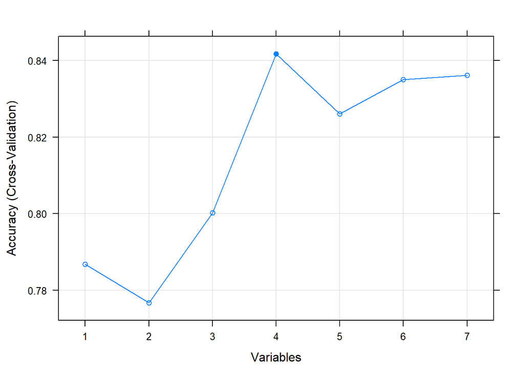

```r
plot(rfe_algorithm, type=c("g", "o"))
```

Vamos passar as features selecionadas para um novo objeto.

```r
data_selected <- full_dataset_transformed %>% select(predictors(rfe_algorithm))
data_selected$Survived <- full_dataset_transformed$Survived
```

Agora entraremos na etapa de criação do modelo. Antes, iremos avaliar um conjunto de modelos que poderíamos selecionar, condunzindo um benchmark. Primeiramente vamos dividir nosso conjunto de dados de treino x teste.

```r
data_selected_train <- data_selected[!is.na(data_selected$Survived),]
data_selected_train$Survived <- as.factor(data_selected_train$Survived)

# 70% treinamento
size_sample <-  floor(0.7 * nrow(data_selected_train))

set.seed(123)
# particionamento randômico
train_ind <- sample(seq_len(nrow(data_selected_train)), size_sample)

# dados de treinamento e teste
data_train <- data_selected_train[train_ind, ]
data_test <- data_selected_train[-train_ind, ]

library(mlr)
library(dplyr)

train_task <- makeClassifTask(data = data_train, target = "Survived")
test_task <- makeClassifTask(data = data_test, target = "Survived")

all_learners = list(
  # Random Forest
  makeLearner("classif.randomForest", id = "Random Forest", predict.type = "prob"),
  # Árvore de decisão
  makeLearner("classif.rpart", id = "RPART", predict.type = "prob"),
  # KNN
  makeLearner("classif.kknn", id = "KNN", predict.type = "prob"),
  # Linear Discriminant Analysis
  makeLearner("classif.lda", id = "LDA", predict.type = "prob"),
  # SVM
  makeLearner("classif.ksvm", id = "SVM",predict.type = "prob"),
  # Naive Bayes
  makeLearner("classif.naiveBayes", id = "Naive Bayes", predict.type = "prob"),
  # Rede Neural
  makeLearner("classif.nnet", id = "Neural Net", predict.type = "prob")
)
```

Agora definimos o método de reamostragem e as medidas de avaliação de perfomance (acurácia e roc). Por fim, passamos isso para a função construir e avaliar a perfomance dos modelos.

```r
# reamostragem
rdesc <- makeResampleDesc("CV", iters = 10)

# medidas que serão utilizadas
meas <- list(acc, auc)

# Definindo o benchmark
bmr <- benchmark(learners = all_learners, tasks = train_task, resamplings = rdesc, measures = meas, show.info = FALSE)
```

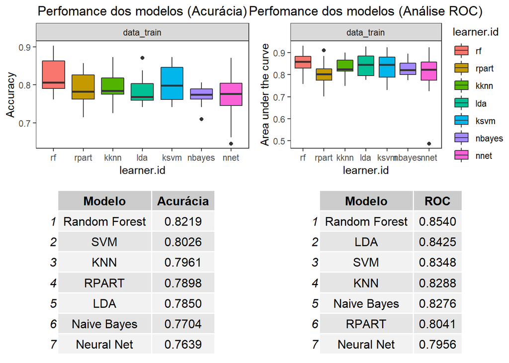

```r
library(gridExtra)
library(ggplot2)

plot_acc<-plotBMRBoxplots(bmr, measure = acc, order.lrns = getBMRLearnerIds(bmr)) +
  ggtitle("Perfomance dos modelos (Acurácia)") +
  aes(fill = learner.id) +
  guides(fill = FALSE) +
  theme_test() +
  theme(plot.title = element_text(hjust = 0.5, vjust = 1))

plot_auc<-plotBMRBoxplots(bmr, measure = auc, order.lrns = getBMRLearnerIds(bmr)) +
  ggtitle("Perfomance dos modelos (Análise ROC)") +
  aes(fill = learner.id) +
  theme_test() +
  theme(plot.title = element_text(hjust = 0.5, vjust = 1))

# Acc
table_acc <- getBMRAggrPerformances(bmr, as.df = TRUE) %>%
  select(Modelo = learner.id, Acurácia = acc.test.mean) %>%
  mutate(Acurácia = round(Acurácia, 4))  %>%
  arrange(desc(Acurácia))

# Roc
table_roc <- getBMRAggrPerformances(bmr, as.df = TRUE) %>%
  select(Modelo = learner.id, ROC = auc.test.mean) %>%
  mutate(ROC = round(ROC, 4))  %>%
  arrange(desc(ROC))

grid.arrange(plot_acc, plot_auc,
  tableGrob(table_acc, theme=ttheme_default()),
  tableGrob(table_roc, theme=ttheme_default()),
  nrow = 2)
```

Assim, decidimos utilizar o Random Forest para construção do modelo. O primeiro passo é preparar o modelo: definir os parâmetros de inicialização e de tuning.

```r
rf <- makeLearner("classif.randomForest", predict.type = "response", par.vals = list(mtry = 3, ntree = 100,
                                                                                     importance = TRUE,
                                                                                     cutoff = c(0.55,0.45)))
# parametros de tuning
parameters <- makeParamSet(
  makeIntegerParam("ntree",lower = 50, upper = 500),
  makeIntegerParam("mtry", lower = 2, upper = 4),
  makeIntegerParam("nodesize", lower = 10, upper = 50)
)

tune <- makeTuneControlRandom(maxit = 100L)

# cv
cv <- makeResampleDesc("CV",iters = 10L)


rf_tune <- tuneParams(learner = rf, resampling = cv, task = train_task, par.set = parameters, control = tune,
                      show.info = TRUE)
```

```
## [Tune] Started tuning learner classif.randomForest for parameter set:
```

```
##             Type len Def    Constr Req Tunable Trafo
## ntree    integer   -   - 50 to 500   -    TRUE     -
## mtry     integer   -   -    2 to 4   -    TRUE     -
## nodesize integer   -   -  10 to 50   -    TRUE     -
```

```
## With control class: TuneControlRandom
```

```
## Imputation value: 1
```

```
## [Tune-x] 1: ntree=242; mtry=3; nodesize=28
```

```
## [Tune-y] 1: mmce.test.mean=0.1990015; time: 0.0 min
```

```
## [Tune-x] 2: ntree=233; mtry=2; nodesize=17
```

```
## [Tune-y] 2: mmce.test.mean=0.2085765; time: 0.0 min
```

```
## [Tune-x] 3: ntree=440; mtry=2; nodesize=38
```

```
## [Tune-y] 3: mmce.test.mean=0.2198413; time: 0.0 min
```

```
## [Tune-x] 4: ntree=496; mtry=4; nodesize=38
```

```
## [Tune-y] 4: mmce.test.mean=0.2069892; time: 0.0 min
```

```
## [Tune-x] 5: ntree=449; mtry=2; nodesize=30
```

```
## [Tune-y] 5: mmce.test.mean=0.2118536; time: 0.0 min
```

```
## [Tune-x] 6: ntree=216; mtry=2; nodesize=37
```

```
## [Tune-y] 6: mmce.test.mean=0.2230671; time: 0.0 min
```

```
## [Tune-x] 7: ntree=96; mtry=3; nodesize=15
```

```
## [Tune-y] 7: mmce.test.mean=0.1829749; time: 0.0 min
```

```
## [Tune-x] 8: ntree=207; mtry=3; nodesize=15
```

```
## [Tune-y] 8: mmce.test.mean=0.1877368; time: 0.0 min
```

```
## [Tune-x] 9: ntree=214; mtry=3; nodesize=33
```

```
## [Tune-y] 9: mmce.test.mean=0.2038146; time: 0.0 min
```

```
## [Tune-x] 10: ntree=50; mtry=2; nodesize=35
```

```
## [Tune-y] 10: mmce.test.mean=0.2214542; time: 0.0 min
```

```
## [Tune-x] 11: ntree=210; mtry=4; nodesize=15
```

```
## [Tune-y] 11: mmce.test.mean=0.1844854; time: 0.0 min
```

```
## [Tune-x] 12: ntree=302; mtry=3; nodesize=27
```

```
## [Tune-y] 12: mmce.test.mean=0.2053507; time: 0.0 min
```

```
## [Tune-x] 13: ntree=76; mtry=2; nodesize=18
```

```
## [Tune-y] 13: mmce.test.mean=0.1941884; time: 0.0 min
```

```
## [Tune-x] 14: ntree=266; mtry=2; nodesize=45
```

```
## [Tune-y] 14: mmce.test.mean=0.2166667; time: 0.0 min
```

```
## [Tune-x] 15: ntree=483; mtry=2; nodesize=38
```

```
## [Tune-y] 15: mmce.test.mean=0.2150538; time: 0.0 min
```

```
## [Tune-x] 16: ntree=476; mtry=2; nodesize=25
```

```
## [Tune-y] 16: mmce.test.mean=0.2118536; time: 0.0 min
```

```
## [Tune-x] 17: ntree=345; mtry=4; nodesize=48
```

```
## [Tune-y] 17: mmce.test.mean=0.2166411; time: 0.0 min
```

```
## [Tune-x] 18: ntree=274; mtry=2; nodesize=30
```

```
## [Tune-y] 18: mmce.test.mean=0.2150538; time: 0.0 min
```

```
## [Tune-x] 19: ntree=199; mtry=2; nodesize=36
```

```
## [Tune-y] 19: mmce.test.mean=0.2198413; time: 0.0 min
```

```
## [Tune-x] 20: ntree=441; mtry=2; nodesize=50
```

```
## [Tune-y] 20: mmce.test.mean=0.2150538; time: 0.0 min
```

```
## [Tune-x] 21: ntree=179; mtry=2; nodesize=47
```

```
## [Tune-y] 21: mmce.test.mean=0.2230671; time: 0.0 min
```

```
## [Tune-x] 22: ntree=107; mtry=3; nodesize=11
```

```
## [Tune-y] 22: mmce.test.mean=0.1749616; time: 0.0 min
```

```
## [Tune-x] 23: ntree=366; mtry=2; nodesize=15
```

```
## [Tune-y] 23: mmce.test.mean=0.2038146; time: 0.0 min
```

```
## [Tune-x] 24: ntree=256; mtry=2; nodesize=36
```

```
## [Tune-y] 24: mmce.test.mean=0.2166923; time: 0.0 min
```

```
## [Tune-x] 25: ntree=465; mtry=2; nodesize=17
```

```
## [Tune-y] 25: mmce.test.mean=0.1941116; time: 0.0 min
```

```
## [Tune-x] 26: ntree=254; mtry=3; nodesize=40
```

```
## [Tune-y] 26: mmce.test.mean=0.2150282; time: 0.0 min
```

```
## [Tune-x] 27: ntree=195; mtry=4; nodesize=48
```

```
## [Tune-y] 27: mmce.test.mean=0.2166155; time: 0.0 min
```

```
## [Tune-x] 28: ntree=427; mtry=4; nodesize=12
```

```
## [Tune-y] 28: mmce.test.mean=0.1828981; time: 0.0 min
```

```
## [Tune-x] 29: ntree=392; mtry=4; nodesize=23
```

```
## [Tune-y] 29: mmce.test.mean=0.2021505; time: 0.0 min
```

```
## [Tune-x] 30: ntree=493; mtry=4; nodesize=50
```

```
## [Tune-y] 30: mmce.test.mean=0.2166411; time: 0.0 min
```

```
## [Tune-x] 31: ntree=466; mtry=3; nodesize=37
```

```
## [Tune-y] 31: mmce.test.mean=0.2150538; time: 0.0 min
```

```
## [Tune-x] 32: ntree=139; mtry=3; nodesize=17
```

```
## [Tune-y] 32: mmce.test.mean=0.1893241; time: 0.0 min
```

```
## [Tune-x] 33: ntree=360; mtry=2; nodesize=43
```

```
## [Tune-y] 33: mmce.test.mean=0.2214798; time: 0.0 min
```

```
## [Tune-x] 34: ntree=496; mtry=3; nodesize=23
```

```
## [Tune-y] 34: mmce.test.mean=0.2069892; time: 0.0 min
```

```
## [Tune-x] 35: ntree=293; mtry=2; nodesize=42
```

```
## [Tune-y] 35: mmce.test.mean=0.2230159; time: 0.0 min
```

```
## [Tune-x] 36: ntree=117; mtry=4; nodesize=30
```

```
## [Tune-y] 36: mmce.test.mean=0.2069636; time: 0.0 min
```

```
## [Tune-x] 37: ntree=61; mtry=2; nodesize=33
```

```
## [Tune-y] 37: mmce.test.mean=0.2087302; time: 0.0 min
```

```
## [Tune-x] 38: ntree=368; mtry=3; nodesize=47
```

```
## [Tune-y] 38: mmce.test.mean=0.2150794; time: 0.0 min
```

```
## [Tune-x] 39: ntree=325; mtry=4; nodesize=19
```

```
## [Tune-y] 39: mmce.test.mean=0.1989503; time: 0.0 min
```

```
## [Tune-x] 40: ntree=72; mtry=3; nodesize=39
```

```
## [Tune-y] 40: mmce.test.mean=0.2198413; time: 0.0 min
```

```
## [Tune-x] 41: ntree=342; mtry=2; nodesize=21
```

```
## [Tune-y] 41: mmce.test.mean=0.2070917; time: 0.0 min
```

```
## [Tune-x] 42: ntree=62; mtry=3; nodesize=28
```

```
## [Tune-y] 42: mmce.test.mean=0.2022273; time: 0.0 min
```

```
## [Tune-x] 43: ntree=184; mtry=4; nodesize=24
```

```
## [Tune-y] 43: mmce.test.mean=0.2021505; time: 0.0 min
```

```
## [Tune-x] 44: ntree=116; mtry=2; nodesize=14
```

```
## [Tune-y] 44: mmce.test.mean=0.1941116; time: 0.0 min
```

```
## [Tune-x] 45: ntree=397; mtry=4; nodesize=12
```

```
## [Tune-y] 45: mmce.test.mean=0.1877368; time: 0.0 min
```

```
## [Tune-x] 46: ntree=290; mtry=3; nodesize=17
```

```
## [Tune-y] 46: mmce.test.mean=0.1941372; time: 0.0 min
```

```
## [Tune-x] 47: ntree=135; mtry=4; nodesize=28
```

```
## [Tune-y] 47: mmce.test.mean=0.2086278; time: 0.0 min
```

```
## [Tune-x] 48: ntree=133; mtry=2; nodesize=27
```

```
## [Tune-y] 48: mmce.test.mean=0.2134409; time: 0.0 min
```

```
## [Tune-x] 49: ntree=128; mtry=2; nodesize=46
```

```
## [Tune-y] 49: mmce.test.mean=0.2166411; time: 0.0 min
```

```
## [Tune-x] 50: ntree=219; mtry=4; nodesize=33
```

```
## [Tune-y] 50: mmce.test.mean=0.2005120; time: 0.0 min
```

```
## [Tune-x] 51: ntree=388; mtry=4; nodesize=19
```

```
## [Tune-y] 51: mmce.test.mean=0.2005888; time: 0.0 min
```

```
## [Tune-x] 52: ntree=143; mtry=3; nodesize=47
```

```
## [Tune-y] 52: mmce.test.mean=0.2150794; time: 0.0 min
```

```
## [Tune-x] 53: ntree=238; mtry=2; nodesize=40
```

```
## [Tune-y] 53: mmce.test.mean=0.2182284; time: 0.0 min
```

```
## [Tune-x] 54: ntree=450; mtry=2; nodesize=33
```

```
## [Tune-y] 54: mmce.test.mean=0.2214542; time: 0.0 min
```

```
## [Tune-x] 55: ntree=354; mtry=4; nodesize=39
```

```
## [Tune-y] 55: mmce.test.mean=0.2053507; time: 0.0 min
```

```
## [Tune-x] 56: ntree=484; mtry=3; nodesize=32
```

```
## [Tune-y] 56: mmce.test.mean=0.2069892; time: 0.0 min
```

```
## [Tune-x] 57: ntree=432; mtry=3; nodesize=46
```

```
## [Tune-y] 57: mmce.test.mean=0.2134921; time: 0.0 min
```

```
## [Tune-x] 58: ntree=52; mtry=2; nodesize=39
```

```
## [Tune-y] 58: mmce.test.mean=0.2214542; time: 0.0 min
```

```
## [Tune-x] 59: ntree=58; mtry=4; nodesize=36
```

```
## [Tune-y] 59: mmce.test.mean=0.1973374; time: 0.0 min
```

```
## [Tune-x] 60: ntree=313; mtry=4; nodesize=17
```

```
## [Tune-y] 60: mmce.test.mean=0.1909370; time: 0.0 min
```

```
## [Tune-x] 61: ntree=218; mtry=4; nodesize=46
```

```
## [Tune-y] 61: mmce.test.mean=0.2166411; time: 0.0 min
```

```
## [Tune-x] 62: ntree=336; mtry=4; nodesize=25
```

```
## [Tune-y] 62: mmce.test.mean=0.2005376; time: 0.0 min
```

```
## [Tune-x] 63: ntree=190; mtry=3; nodesize=34
```

```
## [Tune-y] 63: mmce.test.mean=0.2054275; time: 0.0 min
```

```
## [Tune-x] 64: ntree=80; mtry=2; nodesize=37
```

```
## [Tune-y] 64: mmce.test.mean=0.2182284; time: 0.0 min
```

```
## [Tune-x] 65: ntree=254; mtry=3; nodesize=20
```

```
## [Tune-y] 65: mmce.test.mean=0.1973374; time: 0.0 min
```

```
## [Tune-x] 66: ntree=223; mtry=4; nodesize=19
```

```
## [Tune-y] 66: mmce.test.mean=0.1925243; time: 0.0 min
```

```
## [Tune-x] 67: ntree=400; mtry=2; nodesize=17
```

```
## [Tune-y] 67: mmce.test.mean=0.2005888; time: 0.0 min
```

```
## [Tune-x] 68: ntree=431; mtry=2; nodesize=43
```

```
## [Tune-y] 68: mmce.test.mean=0.2198413; time: 0.0 min
```

```
## [Tune-x] 69: ntree=365; mtry=4; nodesize=33
```

```
## [Tune-y] 69: mmce.test.mean=0.1973374; time: 0.0 min
```

```
## [Tune-x] 70: ntree=146; mtry=2; nodesize=36
```

```
## [Tune-y] 70: mmce.test.mean=0.2311060; time: 0.0 min
```

```
## [Tune-x] 71: ntree=238; mtry=3; nodesize=23
```

```
## [Tune-y] 71: mmce.test.mean=0.2054019; time: 0.0 min
```

```
## [Tune-x] 72: ntree=332; mtry=4; nodesize=24
```

```
## [Tune-y] 72: mmce.test.mean=0.2021249; time: 0.0 min
```

```
## [Tune-x] 73: ntree=410; mtry=4; nodesize=18
```

```
## [Tune-y] 73: mmce.test.mean=0.1957245; time: 0.0 min
```

```
## [Tune-x] 74: ntree=325; mtry=2; nodesize=11
```

```
## [Tune-y] 74: mmce.test.mean=0.1957757; time: 0.0 min
```

```
## [Tune-x] 75: ntree=243; mtry=3; nodesize=48
```

```
## [Tune-y] 75: mmce.test.mean=0.2166667; time: 0.0 min
```

```
## [Tune-x] 76: ntree=319; mtry=4; nodesize=16
```

```
## [Tune-y] 76: mmce.test.mean=0.1941116; time: 0.0 min
```

```
## [Tune-x] 77: ntree=107; mtry=3; nodesize=34
```

```
## [Tune-y] 77: mmce.test.mean=0.2118280; time: 0.0 min
```

```
## [Tune-x] 78: ntree=265; mtry=2; nodesize=26
```

```
## [Tune-y] 78: mmce.test.mean=0.2086534; time: 0.0 min
```

```
## [Tune-x] 79: ntree=165; mtry=2; nodesize=47
```

```
## [Tune-y] 79: mmce.test.mean=0.2182796; time: 0.0 min
```

```
## [Tune-x] 80: ntree=171; mtry=2; nodesize=27
```

```
## [Tune-y] 80: mmce.test.mean=0.2134665; time: 0.0 min
```

```
## [Tune-x] 81: ntree=333; mtry=2; nodesize=40
```

```
## [Tune-y] 81: mmce.test.mean=0.2214798; time: 0.0 min
```

```
## [Tune-x] 82: ntree=203; mtry=2; nodesize=33
```

```
## [Tune-y] 82: mmce.test.mean=0.2117768; time: 0.0 min
```

```
## [Tune-x] 83: ntree=210; mtry=3; nodesize=31
```

```
## [Tune-y] 83: mmce.test.mean=0.2037634; time: 0.0 min
```

```
## [Tune-x] 84: ntree=487; mtry=2; nodesize=26
```

```
## [Tune-y] 84: mmce.test.mean=0.2118024; time: 0.0 min
```

```
## [Tune-x] 85: ntree=254; mtry=3; nodesize=49
```

```
## [Tune-y] 85: mmce.test.mean=0.2118792; time: 0.0 min
```

```
## [Tune-x] 86: ntree=327; mtry=3; nodesize=43
```

```
## [Tune-y] 86: mmce.test.mean=0.2166411; time: 0.0 min
```

```
## [Tune-x] 87: ntree=93; mtry=4; nodesize=16
```

```
## [Tune-y] 87: mmce.test.mean=0.1861495; time: 0.0 min
```

```
## [Tune-x] 88: ntree=443; mtry=3; nodesize=42
```

```
## [Tune-y] 88: mmce.test.mean=0.2182796; time: 0.0 min
```

```
## [Tune-x] 89: ntree=451; mtry=4; nodesize=27
```

```
## [Tune-y] 89: mmce.test.mean=0.2021505; time: 0.0 min
```

```
## [Tune-x] 90: ntree=68; mtry=4; nodesize=45
```

```
## [Tune-y] 90: mmce.test.mean=0.2069892; time: 0.0 min
```

```
## [Tune-x] 91: ntree=452; mtry=2; nodesize=40
```

```
## [Tune-y] 91: mmce.test.mean=0.2230159; time: 0.0 min
```

```
## [Tune-x] 92: ntree=347; mtry=4; nodesize=48
```

```
## [Tune-y] 92: mmce.test.mean=0.2150538; time: 0.0 min
```

```
## [Tune-x] 93: ntree=294; mtry=2; nodesize=22
```

```
## [Tune-y] 93: mmce.test.mean=0.2118280; time: 0.0 min
```

```
## [Tune-x] 94: ntree=319; mtry=4; nodesize=34
```

```
## [Tune-y] 94: mmce.test.mean=0.2054019; time: 0.0 min
```

```
## [Tune-x] 95: ntree=88; mtry=2; nodesize=34
```

```
## [Tune-y] 95: mmce.test.mean=0.2134409; time: 0.0 min
```

```
## [Tune-x] 96: ntree=176; mtry=3; nodesize=36
```

```
## [Tune-y] 96: mmce.test.mean=0.2086278; time: 0.0 min
```

```
## [Tune-x] 97: ntree=136; mtry=3; nodesize=36
```

```
## [Tune-y] 97: mmce.test.mean=0.2166411; time: 0.0 min
```

```
## [Tune-x] 98: ntree=402; mtry=2; nodesize=47
```

```
## [Tune-y] 98: mmce.test.mean=0.2198669; time: 0.0 min
```

```
## [Tune-x] 99: ntree=180; mtry=3; nodesize=41
```

```
## [Tune-y] 99: mmce.test.mean=0.2150282; time: 0.0 min
```

```
## [Tune-x] 100: ntree=92; mtry=4; nodesize=37
```

```
## [Tune-y] 100: mmce.test.mean=0.2021249; time: 0.0 min
```

```
## [Tune] Result: ntree=107; mtry=3; nodesize=11 : mmce.test.mean=0.1749616
```

Agora com os parâmetos de tuning definidos iremos passá-los para a construção do modelo final.

```r
# configurando os hiperparâmetros
rf_tuning <- setHyperPars(rf, par.vals = rf_tune$x)

# configurando os parâmetros de tuning
rf <- mlr::train(rf_tuning, train_task)

# passando o conjunto de teste para o modelo
predict_rf<-predict(rf, test_task)
```

Avaliando a perfomance do modelo.

```r
df <- data.frame(predict_rf$data)

# avaliar os resultados
library(caret)
confusionMatrix(df$response, df$truth)
```

```
## Confusion Matrix and Statistics
##
##           Reference
## Prediction   0   1
##          0 145  26
##          1  22  75
##
##                Accuracy : 0.8209
##                  95% CI : (0.7696, 0.8649)
##     No Information Rate : 0.6231
##     P-Value [Acc > NIR] : 1.461e-12
##
##                   Kappa : 0.6157
##  Mcnemar's Test P-Value : 0.665
##
##             Sensitivity : 0.8683
##             Specificity : 0.7426
##          Pos Pred Value : 0.8480
##          Neg Pred Value : 0.7732
##              Prevalence : 0.6231
##          Detection Rate : 0.5410
##    Detection Prevalence : 0.6381
##       Balanced Accuracy : 0.8054
##
##        'Positive' Class : 0
##
```

```r
library(pROC)
auc(response = df$truth, predictor = factor(df$response, ordered = TRUE))
```

```
## Area under the curve: 0.8054
```

Podemos utilizar o conjunto de teste como uma espécie de validação do modelo, utilizaremos o kaggle como uma plataforma para submeter as respostas sugeridas pelo modelo para os dados de teste. O código está comentado porque já realizamos a submissão e não queremos sobrescrever arquivos no diretório.

```r
# passando o conjunto de teste para o modelo
# data_selected_test <- data_selected[is.na(data_selected$Survived),]
#
# # predição
# predict_rf<-predict(rf$learner.model, data_selected_test)
#
# df <- data.frame(response = predict_rf)
#
# # Acurácia kaggle -> 0.77990
#
# df_predictions <- data.frame(PassengerId = as.numeric(rownames(df)), Survived = df$response)
# head(df_predictions)
# tail(df_predictions)
#
# write.csv(df_predictions,file="data/submits/df_predictions_1.csv", row.names=FALSE)
```

**Etapa adicional**: essa etapa apenas utiliza um outro modelo de fácil interpretação. Se o gestor estiver interessado em entender as regras construidas pelo modelo, poderemos utilizar uma árvore de decisão.

```r
data_selected_train <- data_selected[!is.na(data_selected$Survived),]
data_selected_train$Survived <- as.factor(data_selected_train$Survived)

# 70% treinamento
size_sample <-  floor(0.7 * nrow(data_selected_train))

set.seed(123)
# particionamento randômico
train_ind <- sample(seq_len(nrow(data_selected_train)), size_sample)

# dados de treinamento e teste
data_train <- data_selected_train[train_ind, ]
data_test <- data_selected_train[-train_ind, ]

library(caret)
library(rpart)
library(rpart.plot)
library(e1071)
```

Carregamos e preparamos nosso conjunto de dados de treinamento e teste. Agora construíremos nosso modelo e tentaremos primeiro extrair o melhor valor para cp (parâmetro de complexidade).

```r
library(caret)
library(rpart)
library(rpart.plot)
library(e1071)

control <- trainControl(method = "repeatedcv", number = 10, repeats = 3)

set.seed(123)

# buscando o melhor valor para cp
tree <- caret::train(Survived ~., data = data_train, method = "rpart", parms = list(split = "information"), trControl=control,
          tuneGrid = expand.grid(.cp=(1:50)*0.01))
tree
```

```
## CART
##
## 623 samples
##   4 predictor
##   2 classes: '0', '1'
##
## No pre-processing
## Resampling: Cross-Validated (10 fold, repeated 3 times)
## Summary of sample sizes: 561, 561, 560, 561, 561, 561, ...
## Resampling results across tuning parameters:
##
##   cp    Accuracy   Kappa
##   0.01  0.7929059  0.54421320
##   0.02  0.7838086  0.53312843
##   0.03  0.7897137  0.54998002
##   0.04  0.7897137  0.54998002
##   0.05  0.7897137  0.54998002
##   0.06  0.7897137  0.54998002
##   0.07  0.7897137  0.54998002
##   0.08  0.7897137  0.54998002
##   0.09  0.7897137  0.54998002
##   0.10  0.7897137  0.54998002
##   0.11  0.7897137  0.54998002
##   0.12  0.7897137  0.54998002
##   0.13  0.7897137  0.54998002
##   0.14  0.7897137  0.54998002
##   0.15  0.7897137  0.54998002
##   0.16  0.7897137  0.54998002
##   0.17  0.7897137  0.54998002
##   0.18  0.7897137  0.54998002
##   0.19  0.7897137  0.54998002
##   0.20  0.7897137  0.54998002
##   0.21  0.7897137  0.54998002
##   0.22  0.7897137  0.54998002
##   0.23  0.7897137  0.54998002
##   0.24  0.7897137  0.54998002
##   0.25  0.7897137  0.54998002
##   0.26  0.7897137  0.54998002
##   0.27  0.7897137  0.54998002
##   0.28  0.7897137  0.54998002
```

[output cut: 10 more lines]

```
##   0.39  0.7897137  0.54998002
##   0.40  0.7897137  0.54998002
##   0.41  0.7897137  0.54998002
##   0.42  0.7897137  0.54998002
##   0.43  0.7805740  0.52476490
##   0.44  0.7560988  0.45599239
##   0.45  0.7041835  0.30475179
##   0.46  0.6601999  0.16920610
##   0.47  0.6446938  0.11910795
##   0.48  0.6158493  0.01163904
##   0.49  0.6131611  0.00000000
##   0.50  0.6131611  0.00000000
##
## Accuracy was used to select the optimal model using the largest value.
## The final value used for the model was cp = 0.01.
```

De acordo com o modelo o melhor valor de cp é 0.01. Assim poderemos utilizar esse valor para construção do modelo final.

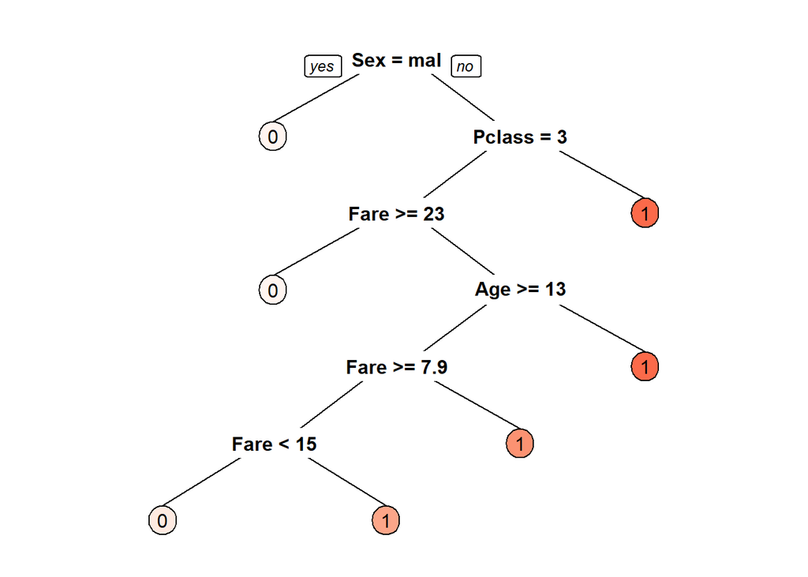

```r
# treinando o modelo a partir do melhor valor para o parâmetro cp
tree_model <- rpart(Survived ~ ., data = data_train, control = rpart.control(cp=tree$results[c(which(tree$results$Accuracy  == max(tree$results$Accuracy))),]$cp))

prp(tree_model, box.palette = "Reds")
```

Observe as regras que foram utilizadas pelo modelo. Em seguida, iremos realizar a tarefa de predição.

```r
# passando o conjunto de teste para o modelo
predict_tree<-predict(tree_model, data_test, type = "class")

df <- data.frame(response = predict_tree)

# avaliar os resultados
library(caret)
confusionMatrix(df$response, data_test$Survived)
```

```
## Confusion Matrix and Statistics
##
##           Reference
## Prediction   0   1
##          0 158  40
##          1   9  61
##
##                Accuracy : 0.8172
##                  95% CI : (0.7656, 0.8616)
##     No Information Rate : 0.6231
##     P-Value [Acc > NIR] : 4.024e-12
##
##                   Kappa : 0.5856
##  Mcnemar's Test P-Value : 1.822e-05
##
##             Sensitivity : 0.9461
##             Specificity : 0.6040
##          Pos Pred Value : 0.7980
##          Neg Pred Value : 0.8714
##              Prevalence : 0.6231
##          Detection Rate : 0.5896
##    Detection Prevalence : 0.7388
##       Balanced Accuracy : 0.7750
##
##        'Positive' Class : 0
##
```

Note que tivemos uma acurácia desejável uma taxa de acerto na classe majoritária cerca de 94,6% aprox. No entanto, o modelo não teve uma boa perfomance na classe minoritária. Podemos suaviazar e estabelecer um melhor trade-off entre FP e FN ao balancer essas classes.

```r
rm(list=ls())

load("data/features_selection.RData")

data_selected_train <- data_selected[!is.na(data_selected$Survived),]
data_selected_train$Survived <- as.factor(data_selected_train$Survived)

library(ROSE)
```

Vamos utilizar o método de over + undersampling para balanceamento de classe. Antes, observe a proporção atual das nossas classes.

```r
prop.table(table(data_selected_train$Survived))
```

```
##
##         0         1
## 0.6161616 0.3838384
```

Então iremos balancear utilizando o método “both” da função ovun.sample().

```r
# método de over e undersampling
balanced_target <- ovun.sample(Survived ~ ., data = data_selected_train, method = "both",N = 950, seed = 1)$data
data_selected_train <- balanced_target
```

Observe que agora a proporção entre as classes melhorou significativamente.

```r
prop.table(table(data_selected_train$Survived))
```

```
##
##         0         1
## 0.5168421 0.4831579
```

Asssim, podemos refazer os passos anteriores.

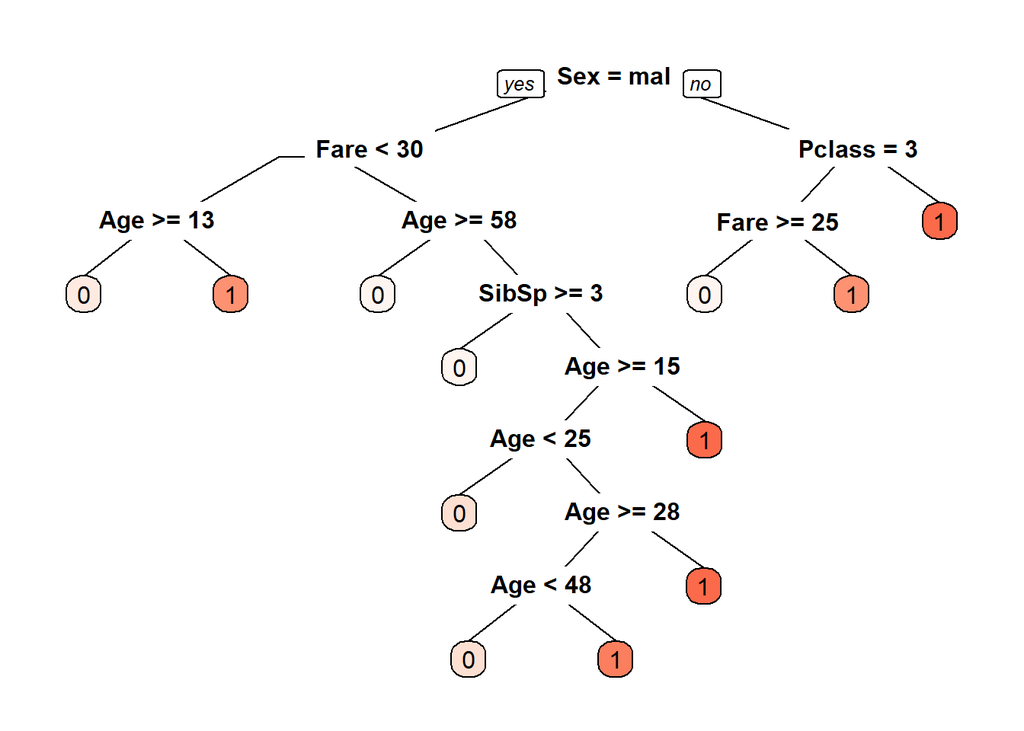

```r
# 70% treinamento
size_sample <-  floor(0.7 * nrow(data_selected_train))

set.seed(123)
# particionamento randômico
train_ind <- sample(seq_len(nrow(data_selected_train)), size_sample)

# dados de treinamento e teste
data_train <- data_selected_train[train_ind, ]
data_test <- data_selected_train[-train_ind, ]

library(caret)
library(rpart)
library(rpart.plot)
library(e1071)

control <- trainControl(method = "repeatedcv", number = 10, repeats = 3)

set.seed(123)

# buscando o melhor valor para cp
tree <- caret::train(Survived ~., data = data_train, method = "rpart", parms = list(split = "information"), trControl=control,
              tuneGrid = expand.grid(.cp=(1:50)*0.01))

# treinando o modelo a partir do melhor valor para o parâmetro cp
tree_model <- rpart(Survived ~ ., data = data_train, control = rpart.control(cp=tree$results[c(which(tree$results$Accuracy  == max(tree$results$Accuracy))),]$cp))

prp(tree_model, box.palette = "Reds")
```

```r
# passando o conjunto de teste para o modelo
predict_tree<-predict(tree_model, data_test, type = "class")

df <- data.frame(response = predict_tree)
```

```r
confusionMatrix(df$response, data_test$Survived)
```

```
## Confusion Matrix and Statistics
##
##           Reference
## Prediction   0   1
##          0 132  23
##          1  24 106
##
##                Accuracy : 0.8351
##                  95% CI : (0.7868, 0.8762)
##     No Information Rate : 0.5474
##     P-Value [Acc > NIR] : <2e-16
##
##                   Kappa : 0.6674
##  Mcnemar's Test P-Value : 1
##
##             Sensitivity : 0.8462
##             Specificity : 0.8217
##          Pos Pred Value : 0.8516
##          Neg Pred Value : 0.8154
##              Prevalence : 0.5474
##          Detection Rate : 0.4632
##    Detection Prevalence : 0.5439
##       Balanced Accuracy : 0.8339
##
##        'Positive' Class : 0
##
```